# Refractory Septic Shock Incidence and Outcomes

Author

Seth Bauer

Published

2026-04-07

# 1 Overview

Refractory septic shock was recently defined and clinical criteria established per a Delphi consensus process (Leone, [under peer review]). However, the incidence of refractory septic shock per clinical criteria and comparative outcomes between patients meeting and not meeting criteria are unknown. This retrospective cohort study was designed with two co-primary goals; 1a) to describe the cumulative incidence of refractory septic shock per clinical criteria, and 1b) to compare characteristics and outcomes of patients with septic shock who met and did not meet clinical criteria for refractory septic shock.

# 2 Load Packages and Setup

```r
knitr::opts_chunk$set(comment = NA)
options(width = 70)

library(broom.mixed); library(conflicted); library(Epi);
library(flextable); library(gtsummary); library(ivs);
library(janitor); library(kableExtra); library(lme4);
library(MKinfer); #For `boot.t.test` function
library(naniar); library(patchwork); library(report); library(renv);
library(scales); library(vroom); library(tidyverse)

theme_set(theme_bw())

conflict_prefer("count", "dplyr"); conflict_prefer("select", "dplyr");
conflict_prefer("filter", "dplyr"); conflict_prefer("recode", "dplyr");
conflict_prefer("min", "base"); conflict_prefer("max", "base");
conflict_prefer("var", "stats"); conflict_prefer("data.frame", "base");
conflict_prefer("sum", "base"); conflict_prefer("mean", "base")
```

# 3 Load Data

Read in the data from .Rds files created in previous work. Each source .Rds file utilized multiple input files or queries, which will not be iterated here. See [Bauer 2025](https://link.springer.com/article/10.1186/s13054-025-05749-1) and the [open source Quarto Documents](https://github.com/ClevelandClinicQHS/sepsis-case-identification-workflow) for the process steps to build the patient cohorts and .Rds files. Also load a file containing a lookup table of emergency department and hospital characteristics. The data sources for this document are:

| Tibble | File (.Rds) | Source Quarto Document (.qmd) |
| --- | --- | --- |
| shock | shock | sepsis_combined |
| pressors_courses | vasopressors_courses | vasopressors |
| pressors_doses | vasopressors_long | vasopressors |
| hosp_char | Hospital_characteristics.csv | none (raw file) |
| body_weight | weight | weight |
| comor | comorbidities | comorbidities |
| sofa | sofa_daily | sofa_daily |
| lactate | lactate_all | lactate |
| steroids | steroids | steroids |

Some .Rds files include all observations in the raw queries, but in this work only observations from patients meeting clinical criteria for septic shock are of interest. Therefore, as applicable, the call below filters observations to those from septic shock cases. This call also selects vectors (columns) of interest for this work, clarifies the name of one hospital location, adjusts vector structure as needed, and drops unused levels of factor variables.

```r
shock_orig <- read_rds(
  "/proj/DaltonLab/projects/sbauer/rds_files/shock.Rds"
  ) |>
  filter(shock_ase == "ASE" | shock_sepsis3 == "Sep3") |>
  select(-contains("icd")) |>
  rename(criteria_met = shock_combined) |>
  mutate(shock_ase_onset_hospital =
           if_else(shock_ase_onset_hospital == "Martin Health St. Lucie West",
                   "Martin Health South", shock_ase_onset_hospital
                   ),
         shock_sep3_onset_hospital =
           if_else(shock_sep3_onset_hospital == "Martin Health St. Lucie West",
                   "Martin Health South", shock_sep3_onset_hospital
                   ),
         across(where(is.factor), droplevels)
         )

pressors_courses <- read_rds(
  "/proj/DaltonLab/projects/sbauer/rds_files/vasopressors_courses.Rds"
  ) |>
  filter(encounter_id %in% shock_orig$encounter_id) |>
  select(encounter_id, medication, start_time, stop_time) |>
  mutate(medication = fct_relevel(factor(medication), "norepinephrine",
                                  "dopamine","phenylephrine", "epinephrine",
                                  "vasopressin"
                                  )
         ) |>
  arrange(encounter_id, medication, start_time)

pressors_doses <- read_rds(
  "/proj/DaltonLab/projects/sbauer/rds_files/vasopressors_long.Rds"
  ) |>
  filter(encounter_id %in% shock_orig$encounter_id) |>
  select(-c(dose_mcg_min, dose_mcg_kg_min, dose_units_min))

hosp_char <-
  vroom("/proj/DaltonLab/projects/sbauer/data_raw/full_cohort/Hospital_characteristics.csv",
        col_types = c(hospital = "f", hosp_beds = "f", hosp_beds_cat = "f",
                      hosp_teaching_status = "f", hosp_state = "f"))

body_weight <-
  read_rds("/proj/DaltonLab/projects/sbauer/rds_files/weight.Rds") |>
  filter(encounter_id %in% shock_orig$encounter_id)

comor <-
  read_rds("/proj/DaltonLab/projects/sbauer/rds_files/comorbidities.Rds") |>
  filter(encounter_id %in% shock_orig$encounter_id)

sofa <-
  read_rds("/proj/DaltonLab/projects/sbauer/rds_files/sofa_daily.Rds") |>
  filter(encounter_id %in% shock_orig$encounter_id)

lactate <- read_rds(
  "/proj/DaltonLab/projects/sbauer/rds_files/lactate_all.Rds") |>
  filter(encounter_id %in% shock_orig$encounter_id) |>
  select(encounter_id, lactate_time = lactate_taken_time,
         lactate = lactate_result, lactate_type)

steroids <- read_rds(
  "/proj/DaltonLab/projects/sbauer/rds_files/steroids.Rds") |>
  filter(encounter_id %in% shock_orig$encounter_id)
```

Next, confirm that the `encounter_id`s are the same between `shock_orig` and `pressors_courses` as well as between `shock_orig` and `pressors_doses`.

```r
setequal(shock_orig$encounter_id, pressors_courses$encounter_id)
```

```
[1] TRUE
```

```r
setequal(shock_orig$encounter_id, pressors_doses$encounter_id)
```

```
[1] TRUE
```

# 4 Data Transformation

Next, select vectors already in the tibble that will be used for analysis. Then identify and create vectors for characteristics and outcomes that will be used for analysis.

## 4.1 Select Variables

With the call below, select variables (vectors) of interest in the `shock` tibble that will be used for joining data between tibbles or for analysis. To align with this goal, some vectors need to be created based on the sepsis or septic shock onset time, which may differ between the CDC ASE and Sepsis-3 criteria. Because the onset time for the CDC ASE criteria is transparently outlined (whereas it is unclear for Sepsis-3 clinical criteria), when an observation met CDC ASE criteria (including the cohorts meeting both CDC ASE and Sepsis-3 criteria as well as the cohort meeting CDC ASE criteria only), the values aligning with the sepsis onset time for CDC ASE will be used. If CDC ASE criteria were not met then values aligning with the Sepsis-3 onset time will be used. This approach is aligned with the description in the cohort development manuscript ([Bauer 2025](https://link.springer.com/article/10.1186/s13054-025-05749-1)). To simplify the call, if the case only met Sepsis-3 criteria, the values corresponding to Sepsis-3 will be used. In the remaining cases (when only CDC ASE criteria were met or both criteria were met), the CDC ASE criteria will be used. Vectors containing the term “either” (meaning either CDC ASE or Sepsis-3 criteria were met for the encounter) already use the CDC ASE onset time, as applicable, therefore these vectors will be selected. Some observation concepts did not have a vector with the term “either” created in the cohort development process, therefore these vectors will be created in the call using the same logic. Additionally, rename some vectors for simplicity and clarity, including removal of the prefix “either_”.

```r
shock <- shock_orig |>
  mutate(sepsis_window_start = if_else(criteria_met == "Sep3 only",
                                       sep3_window_start,
                                       ase_window_start
                                       ),
         sepsis_window_end = if_else(criteria_met == "Sep3 only",
                                     sep3_window_end,
                                     ase_window_end
                                     ),
         sepsis_onset_hospital = if_else(criteria_met == "Sep3 only",
                                         sep3_dx_hospital,
                                         ase_dx_hospital),
         sepsis_onset_icu_group = if_else(criteria_met == "Sep3 only",
                                          sep3_onset_icu_group,
                                          ase_onset_icu_group
                                          ),
         sepsis_onset_covid = if_else(criteria_met == "Sep3 only",
                                      sep3_onset_covid,
                                      ase_onset_covid),
         shock_onset_time = if_else(criteria_met == "Sep3 only",
                                    shock_sep3_onset_time,
                                    shock_ase_onset_time),
         shock_onset_unit_type = if_else(criteria_met == "Sep3 only",
                                         shock_sep3_onset_unit_type,
                                         shock_ase_onset_unit_type),
         shock_onset_hospital = if_else(criteria_met == "Sep3 only",
                                        shock_sep3_onset_hospital,
                                        shock_ase_onset_hospital
                                        ),
          shock_onset_icu_group =
           if_else(criteria_met == "Sep3 only",
                   shock_sep3_onset_icu_group,
                   shock_ase_onset_icu_group
                   )
         ) |>
  rename(admission_time = key_admission_time,
         sepsis_onset_tot_sofa = either_tot_sofa,
         sepsis_onset_unit_type = either_onset_unit_type,
         encounter_max_sofa = max_sofa,
         sepsis_3 = shock_sepsis3) |>
  select(-contains(c("ase", "sep3", "sepsis3", "combined")),
         -c(patient_id, encounter_id_orig, key_discharge_time, first_sepsis,
            race, ethnicity, sepsis_either, sepsis_any,
            shock_either, shock_exclusive, sepsis_clin_v_code,
            shock_clin_v_code, either_dx_hosp_beds_cat, either_dx_hosp_state,
            either_dx_hosp_teaching_status, either_shock_map_min,
            either_shock_pressor, either_shock_lactate_max,
            either_prior_surg_service, surgery_30d_prior_to_dc,
            surg_service_30d_prior_to_dc, dc_hospital, dc_hosp_state,
            dc_hosp_beds_cat, dc_hosp_teaching_status, any_icu_admit,
            bcx_collected, either_abx_days
            )
         ) |>
  rename_with(~ str_replace_all(.x, c("^either_" = "",
                                      "^dx_" = "sepsis_onset_"
                                      )
                                )
              )
```

Now check the vector names in the `shock` tibble to confirm the vectors of interest are included.

```r
names(shock)
```

```
 [1] "encounter_id"              "admission_time"
 [3] "sepsis_3"                  "criteria_met"
 [5] "age"                       "sex"
 [7] "race_eth"                  "admit_year"
 [9] "admit_year_cat"            "mort_hosp"
[11] "los_hosp_days"             "dc_dispo_f"
[13] "comm_onset"                "encounter_max_sofa"
[15] "sepsis_onset_tot_sofa"     "cv_organ_dysfxn"
[17] "resp_organ_dysfxn"         "kidney_organ_dysfxn"
[19] "liver_organ_dysfxn"        "coag_organ_dysfxn"
[21] "lactate_organ_dysfxn"      "brain_organ_dysfxn"
[23] "mv_any"                    "covid_positive_through_dc"
[25] "prior_surg"                "sepsis_onset_unit_type"
[27] "shock_map_closest"         "shock_lactate_closest"
[29] "shock_onset_tot_sofa"      "mv_before_shock"
[31] "sepsis_window_start"       "sepsis_window_end"
[33] "sepsis_onset_hospital"     "sepsis_onset_icu_group"
[35] "sepsis_onset_covid"        "shock_onset_time"
[37] "shock_onset_unit_type"     "shock_onset_hospital"
[39] "shock_onset_icu_group"
```

The retained vectors are consistent with expectations.

## 4.2 Create Variables

This sub-section will create and join the cohort identifier (refractory septic shock) as well as patient and hospital characteristics of interest that are not yet included in the `shock` tibble.

### 4.2.1 Biological Variables

Many of the covariates (predictors) of interest are in the `shock` tibble already, but some additional covariates of interest need to be joined from other loaded tibbles.

#### 4.2.1.1 Body Weight

Join body weight at shock onset. The first preference for weight is the closest value prior to shock onset. If a weight value prior to shock onset is not available, then use weight taken within 24 hours after shock onset.

```r
shock <- left_join(
  shock |> mutate(shock_onset_time_plus_24h = shock_onset_time + dhours(24)),
  body_weight |> select(encounter_id, wt_time, wt_kg) |> distinct(),
  by = join_by(encounter_id,
               closest(shock_onset_time >= wt_time)
               ),
  relationship = "one-to-one"
  ) |>
  left_join(
    body_weight |> select(encounter_id, wt_time_wi24h = wt_time,
                     wt_kg_wi24h = wt_kg) |> distinct(),
    by = join_by(encounter_id,
                 shock_onset_time_plus_24h > wt_time_wi24h
                 ),
    relationship = "one-to-many"
  ) |>
  arrange(encounter_id, shock_onset_time, shock_onset_time_plus_24h) |>
  distinct(encounter_id, .keep_all = TRUE) |>
  mutate(wt_kg = coalesce(wt_kg, wt_kg_wi24h),
         wt_time = coalesce(wt_time, wt_time_wi24h)
         ) |>
  select(-c(shock_onset_time, shock_onset_time_plus_24h, wt_time,
            wt_time_wi24h, wt_kg_wi24h
            ))
```

Lastly, remove the `body_weight` tibble since it won’t be used moving forward.

```r
rm(body_weight)
```

#### 4.2.1.2 Comorbidities

Join comorbidity data from the `comor` tibble. In this process consolidate some vectors representing illness severity into one vector, indicating presence or absence of the comorbidity (without regard to severity).

```r
shock <- left_join(
  shock,
  comor |>
    mutate(hypertension =
             if_else(hypertension_uncomplicated == "Yes" |
                       hypertension_complicated == "Yes",
                     "Yes", "No"
                     ),
           liver_disease =
             if_else(liver_disease_mild == "Yes" |
                       liver_disease_and_failure == "Yes",
                     "Yes", "No"
                     ),
           kidney_disease =
             if_else(renal_kidney_failure_and_disease_moderate == "Yes" |
                       renal_kidney_failure_and_disease_severe == "Yes",
                     "Yes", "No"
                     ),
           malignancy =
             if_else(leukemia == "Yes" | lymphoma == "Yes" |
                       metastatic_cancer == "Yes" |
                       solid_tumor_without_metastasis == "Yes",
                     "Yes", "No"
                     ),
           diabetes =
             if_else(diabetes_without_chronic_complications == "Yes" |
                       diabetes_with_chronic_complications == "Yes",
                     "Yes", "No"
                     ),
           ) |>
              select(encounter_id, cerebrovascular_disease, hypertension,
                     heart_failure, valvular_disease,
                     chronic_pulmonary_disease, pulmonary_circulation_disease,
                     liver_disease, kidney_disease, malignancy, diabetes,
                     obesity, alcohol_abuse, elixhauser_index
                     ),
  by = join_by(encounter_id),
  relationship = "one-to-one"
  )
```

Some patients (`encounter_id`s) were not present in the `comor` tibble because they did not have a chronic comorbidity as assessed with the Elixhauser Comorbidity Index. In these cases the comorbidity vectors will have values of “NA”. Replace these “NA” values with “No” for the comorbidity vectors and zero for the `elixhauser_index` vector in the call below.

```r
shock <- shock |>
  mutate(
    across(
      c(cerebrovascular_disease, hypertension,
        heart_failure, valvular_disease, alcohol_abuse,
        chronic_pulmonary_disease, pulmonary_circulation_disease,
        liver_disease, kidney_disease, malignancy, diabetes, obesity
        ),
      ~ fct_na_value_to_level(.x, "No")
    ),
    elixhauser_index = replace_na(elixhauser_index, 0)
  )
```

Lastly, remove the `comor` tibble since it won’t be used moving forward.

```r
rm(comor)
```

### 4.2.2 Context Characteristics

#### 4.2.2.1 Shock Onset Treatment Unit

The `shock` tibble has a vector (`shock_onset_unit_type`) for the initial shock treatment location with levels “ED”, “Ward”, and “ICU”, but this is too broad for the purposes of this study. Contrastingly, the `shock_onset_icu_group` vector for ICU designations is too granular for external applicability. Therefore a new vector (`shock_onset_tx_unit`) will be created that combines information from these vectors to generate categories. As noted in the cohort identification work, there are observations with missing values for `shock_onset_unit_type` where the onset time was between the admission and discharge time for emergency department or hospital admissions linked through the `encounter_id`. For these cases with missing values the `sepsis_onset_unit_type` vector will be used when available; if values for both `shock_onset_unit_type` and `sepsis_onset_unit_type` are missing then the value will be regarded as missing (NA). Lastly, remove the `*_unit_type` and `*_icu_group` vectors because they won’t be used moving forward.

```r
shock <- shock |> mutate(shock_onset_tx_unit = factor(case_when(
  shock_onset_unit_type == "ED" ~ "ED",
  shock_onset_unit_type == "ICU" &
    grepl("MICU|CCU", shock_onset_icu_group) ~ "Medical/Cardiac ICU",
  shock_onset_unit_type == "ICU" &
    grepl("SICU|CVICU", shock_onset_icu_group) ~ "Surgical ICU",
  shock_onset_unit_type == "ICU" ~ "Mixed Med/Surg ICU",
  shock_onset_unit_type == "Ward" ~ "Ward",
  is.na(shock_onset_unit_type) &
    sepsis_onset_unit_type == "ED" ~ "ED",
  is.na(shock_onset_unit_type) &
    grepl("MICU|CCU", sepsis_onset_icu_group) ~ "Medical/Cardiac ICU",
  is.na(shock_onset_unit_type) &
    grepl("SICU|CVICU", sepsis_onset_icu_group) ~ "Surgical ICU",
  is.na(shock_onset_unit_type) &
    sepsis_onset_unit_type == "ICU" ~ "Mixed Med/Surg ICU",
  is.na(shock_onset_unit_type) &
    sepsis_onset_unit_type == "Ward" ~ "Ward",
  .default = NA
  ))) |>
  select(-c(sepsis_onset_unit_type, sepsis_onset_icu_group,
            shock_onset_unit_type, shock_onset_icu_group))
```

Now show the distribution of values to ensure expectations are met.

```r
shock |> tabyl(shock_onset_tx_unit) |> adorn_pct_formatting() |>
  adorn_totals() |>
  rename("Shock Onset Treatment Unit" = "shock_onset_tx_unit") |>
  kable(align = c('lcc')) |>
  kable_paper(full_width = FALSE)
```

| Shock Onset Treatment Unit | n | percent | valid_percent |
| --- | --- | --- | --- |
| ED | 7566 | 21.1% | 21.1% |
| Medical/Cardiac ICU | 10099 | 28.1% | 28.1% |
| Mixed Med/Surg ICU | 7827 | 21.8% | 21.8% |
| Surgical ICU | 9332 | 26.0% | 26.0% |
| Ward | 1086 | 3.0% | 3.0% |
| NA | 4 | 0.0% | - |
| Total | 35914 | - | - |

#### 4.2.2.2 Hospital Characteristics

First, join characteristics of the hospital at shock onset. In the rare case of a missing hospital at shock, use hospital at sepsis onset since this hospital is either the same or the hospital immediately preceding a care transfer. Then, remove the `sepsis_onset_hospital` vector because it won’t be used moving forward.

```r
shock <- shock |>
  mutate(shock_onset_hospital = if_else(is.na(shock_onset_hospital),
                                        sepsis_onset_hospital,
                                        shock_onset_hospital
                                        )
         ) |>
  left_join(hosp_char |> select(hospital, hosp_beds_cat, hosp_teaching_status,
                                hosp_state),
            by = join_by(shock_onset_hospital == hospital),
            relationship = "many-to-one"
  ) |>
  rename(shock_onset_hosp_beds_cat = hosp_beds_cat,
         shock_onset_hosp_teaching_status = hosp_teaching_status,
         shock_onset_hosp_state = hosp_state
  ) |>
  select(-sepsis_onset_hospital)
```

Lastly, remove the `hosp_char` tibble since it won’t be used moving forward.

```r
rm(hosp_char)
```

### 4.2.3 Shock Characteristics

#### 4.2.3.1 First Vasopressor

Identify the first vasopressor administered. To develop this variable, need to determine the date/time range of vasopressor administration.

First, join the necessary data points from the `shock` tibble to the `pressors_courses` tibble (in a new tibble called `pressors`).

```r
pressors <- pressors_courses |>
  left_join(shock |>
              select(encounter_id, sepsis_window_start, sepsis_window_end),
            by = join_by(encounter_id),
            relationship = "many-to-one"
            )
```

As a reference point to ensure consistency with manipulation steps below, count the number of distinct `encounter_id`s in the `pressors` tibble and ensure the `encounter_id`s match with the `shock` tibble.

```r
n_distinct(pressors$encounter_id)
```

```
[1] 35914
```

```r
setequal(shock$encounter_id, pressors$encounter_id)
```

```
[1] TRUE
```

There are 35,914 distinct septic shock cases meeting either or both CDC ASE and Sepsis-3 criteria. The `encounter_id`s contained in `pressors` tibble match those in the `shock` tibble. Consistency with this count will be ensured in the subsequent work in this section.

```r
pressors <- pressors |>
  mutate(start_stop_range = iv(start_time, stop_time + 1)) |>
  group_by(encounter_id) |>
  mutate(pressors_range = iv_identify_group(start_stop_range, abutting = TRUE),
         sepsis_window = iv(sepsis_window_start, sepsis_window_end + 1),
         pressor_during_window =
           iv_pairwise_overlaps(pressors_range, sepsis_window, type = "any"),
         pressors_dur_hours =
           as.duration(iv_start(pressors_range) %--% iv_end(pressors_range)) /
                          dhours(1)
         ) |>
  filter(pressor_during_window == TRUE) |>
  filter(pressors_range == min(pressors_range)) |>
  ungroup() |>
  arrange(encounter_id, pressors_range, start_time) |>
  select(-c(start_stop_range, sepsis_window_start, sepsis_window_end,
         sepsis_window, pressor_during_window
         ))
```

The `pressors` tibble now only includes the first vasopressor course that was administered during a time that overlapped with the sepsis “window period”.

Now adjudicate the first vasopressor medication during the vasopressor course, which is useful for aligning adjunctive vasopressor use and timing. In the call, also identify cases where multiple vasopressors are started first at the same time (as `multiple_first`).

```r
pressors <- pressors |>
  group_by(encounter_id, pressors_range) |>
  mutate(temp1 = if_else(start_time == iv_start(pressors_range), 1, 0),
         temp2 = if_else(cumsum(temp1) >1, "Yes", "No"),
         multiple_first = if_else(any(temp2 == "Yes"), "Yes", "No")
         ) |>
  select(-temp1, -temp2) |>
  mutate(first_pressor = if_else(start_time == iv_start(pressors_range),
                                   medication, NA
                                 ),
         .after = pressors_range
         ) |>
  fill(first_pressor, .direction = "down") |>
  ungroup()
```

Next, reconcile the case with multiple first vasopressors (`multiple_first` == “Yes”). Since norepinephrine has been recommended by the Surviving Sepsis Campaign Guidelines throughout the cohort time period as a first-line vasopressor, if this vasopressor is present, consider the first vasopressor norepinephrine. Second, since at one time dopamine was recommended as a first-line vasopressor, consider dopamine the first vasopressor if norepinephrine is not present. Then consider other vasopressors according to this hierarchy corresponding to recommendations in the Surviving Sepsis Campaign Guidelines: epinephrine, phenylephrine, then vasopressin. Lastly, remove the `multiple_first` vector since it won’t be used moving forward.

```r
pressors <- pressors |>
  group_by(encounter_id) |>
  mutate(first_pressor = factor(case_when(
    multiple_first == "Yes" &
      any(first_pressor == "norepinephrine") ~ "norepinephrine",
    multiple_first == "Yes" &
      any(first_pressor == "dopmaine") ~ "dopamine",
    multiple_first == "Yes" &
      any(first_pressor == "epinephrine") ~ "epinephrine",
    multiple_first == "Yes" &
      any(first_pressor == "phenylephrine") ~ "phenylephrine",
    multiple_first == "Yes" &
      any(first_pressor == "vasopressin") ~ "vasopressin",
    .default = first_pressor
      ))) |>
  ungroup() |>
  select(-multiple_first)
```

Check that the encounters retained are correct.

```r
setequal(shock$encounter_id, pressors$encounter_id)
```

```
[1] FALSE
```

```r
pressors |>
  tabyl(first_pressor) |> adorn_totals() |> adorn_pct_formatting() |>
  kable(align = c('lcc'),
        caption = "First Vasopressor"
        ) |>
  kable_paper(full_width = FALSE)
```

First Vasopressor

| first_pressor | n | percent |
| --- | --- | --- |
| norepinephrine | 48016 | 76.8% |
| phenylephrine | 5664 | 9.1% |
| epinephrine | 4853 | 7.8% |
| dopamine | 1695 | 2.7% |
| vasopressin | 2277 | 3.6% |
| Total | 62505 | 100.0% |

The count of first vasopressor is very similar, but not exactly the same as the count in the “Either CDC ASE or Sepsis-3 Criteria” septic shock group reported in the case identification work for this project. The reason for the minor discrepancy likely relates to a difference in the arrangement (ordering) of `encounter_id`s prior to the application of the `distinct()` function in the original work, which influences which medication is tabulated in cases where multiple vasopressor drugs were administered first.

Join the vasopressor course vectors created in this section to the `shock` tibble.

```r
shock <- shock |>
  left_join(pressors |> distinct(encounter_id, .keep_all = TRUE) |>
              select(encounter_id, first_pressor, pressors_range,
                     pressors_dur_hours
                     ),
            by = join_by(encounter_id),
            relationship = "one-to-one"
            )
```

Lastly, remove the `pressors_courses` tibble since it won’t be used moving forward.

```r
rm(pressors_courses)
```

#### 4.2.3.2 Adjunctive Vasopressor

Next, adjudicate adjunctive vasopressor use. The vasopressor medication start and stop time data are in long format, but the data need to be in wide format for this adjudication. The call below converts to a wide format for the start of each vasopressor medication. When there are multiple administrations of the same vasopressor, only keep the first administration (the earliest `start_time`, which is the “values_fn = min” portion of the call).

```r
pressors_wide <- pressors |>
  rename(start = start_time, stop = stop_time) |>
  pivot_wider(
    id_cols = c(encounter_id, pressors_range, pressors_dur_hours,
                first_pressor
                ),
    names_from = medication,
    values_from = c(start, stop),
    names_glue = "{medication}_{.value}",
    values_fn = min
    )
```

First, create internal vectors for each vasopressor start time.

```r
pressors_wide <- pressors_wide |>
  mutate(ne_start_iv = iv(norepinephrine_start, norepinephrine_start + 1),
         avp_start_iv = iv(vasopressin_start, vasopressin_start + 1),
         epi_start_iv = iv(epinephrine_start, epinephrine_start + 1),
         pe_start_iv = iv(phenylephrine_start, phenylephrine_start + 1),
         da_start_iv = iv(dopamine_start, dopamine_start + 1)
         )
```

Next, assess adjunctive vasopressor use (including third through fifth line vasopressor use) based on the individual vasopressor start time being within the `pressors_range` internal vector time period.

```r
pressors_wide <- pressors_wide |>
  mutate(
    adj_avp = if_else(
      first_pressor != "vasopressin" &
        iv_pairwise_overlaps(avp_start_iv, pressors_range,
                             type = "within") == TRUE, 1, 0),
    adj_avp = if_else(is.na(adj_avp), 0, adj_avp),
    adj_epi = if_else(
      first_pressor != "epinephrine" &
        iv_pairwise_overlaps(epi_start_iv, pressors_range,
                             type = "within") == TRUE, 1, 0),
    adj_epi = if_else(is.na(adj_epi), 0, adj_epi),
    adj_pe = if_else(
      first_pressor != "phenylephrine" &
        iv_pairwise_overlaps(pe_start_iv, pressors_range,
                             type = "within") == TRUE, 1, 0),
    adj_pe = if_else(is.na(adj_pe), 0, adj_pe),
    adj_da = if_else(
      first_pressor != "dopamine" &
        iv_pairwise_overlaps(da_start_iv, pressors_range,
                             type = "within") == TRUE, 1, 0),
    adj_da = if_else(is.na(adj_da), 0, adj_da),
    adj_ne = if_else(
      first_pressor != "norepinephrine" &
        iv_pairwise_overlaps(ne_start_iv, pressors_range,
                             type = "within") == TRUE, 1, 0),
    adj_ne = if_else(is.na(adj_ne), 0, adj_ne)
    ) |>
  select(-(ends_with("_iv")))
```

Now, determine the time to adjunctive agent initiation, which is a necessary step to calculate the “second-line” (first adjunct) vasopressor.

```r
pressors_wide <- pressors_wide |>
  mutate(time_to_adj_ne =
           if_else(adj_ne == 1,
                   round_half_up(
                     as.duration(iv_start(pressors_range) %--%
                                   norepinephrine_start) / dhours(1), 2),
                   NA),
         time_to_adj_avp =
           if_else(adj_avp == 1,
                   round_half_up(
                     as.duration(iv_start(pressors_range) %--%
                                   vasopressin_start) / dhours(1), 2),
                   NA),
         time_to_adj_epi =
           if_else(adj_epi == 1,
                   round_half_up(
                     as.duration(iv_start(pressors_range) %--%
                                   epinephrine_start) / dhours(1), 2),
                   NA),
         time_to_adj_pe =
           if_else(adj_pe == 1,
                   round_half_up(
                     as.duration(iv_start(pressors_range) %--%
                                   phenylephrine_start) / dhours(1), 2),
                   NA),
         time_to_adj_da =
           if_else(adj_da == 1,
                   round_half_up(
                     as.duration(iv_start(pressors_range) %--%
                                   dopamine_start) / dhours(1), 2),
                   NA)
         )
```

Then, assign adjunctive vasopressor use a rank based on the time to initiation after shock onset (vasopressor initiation). In this call, one will be added to the rank because the formula calculates the first medication based on time. Since only adjuncts are evaluated, an initial (first) vasopressor was already administered, and the logical order for adjuncts will be second or higher.

```r
# Reshape to long format (required for ranking)
pressors_long <- pivot_longer(pressors_wide,
                              cols = starts_with("time_to"),
                              names_to = "Variable",
                              values_to = "Date")

# Rank the dates/times within each encounter_id
pressors_long <- pressors_long |>
  group_by(encounter_id) |>
  mutate(Rank = rank(Date))

# Reshape back to wide format and assign to main tibble name
pressors <- pivot_wider(pressors_long,
                        names_from = Variable, values_from = c(Date, Rank)) |>
  rename(time_to_adj_ne = Date_time_to_adj_ne,
         time_to_adj_avp = Date_time_to_adj_avp,
         time_to_adj_epi = Date_time_to_adj_epi,
         time_to_adj_pe = Date_time_to_adj_pe,
         time_to_adj_da = Date_time_to_adj_da
         ) |>
  mutate(adj_ne_order = if_else(adj_ne == 0, NA, Rank_time_to_adj_ne + 1),
         adj_avp_order = if_else(adj_avp == 0, NA, Rank_time_to_adj_avp + 1),
         adj_epi_order = if_else(adj_epi == 0, NA, Rank_time_to_adj_epi + 1),
         adj_pe_order = if_else(adj_pe == 0, NA, Rank_time_to_adj_pe + 1),
         adj_da_order = if_else(adj_da == 0, NA, Rank_time_to_adj_da + 1)
         ) |>
  select(-Rank_time_to_adj_ne, -Rank_time_to_adj_avp, -Rank_time_to_adj_epi,
         -Rank_time_to_adj_pe, -Rank_time_to_adj_da
         )

# Remove long and wide tibbles
rm(pressors_long, pressors_wide)
```

Next, adjudicate any adjunct presence and time to first adjunct. If an adjunct was not present/used, then the time to first adjunct will be NA.

```r
pressors <- pressors |>
  group_by(encounter_id, first_pressor) |>
  mutate(any_adj =
           factor(if_else(any(adj_ne == 1, adj_avp == 1, adj_epi == 1,
                              adj_pe == 1, adj_da == 1),
                          "Adjunct", "No Adjunct"
                          )),
         hours_to_first_adj =
           if_else(any_adj == "Adjunct",
                   pmin(time_to_adj_ne, time_to_adj_avp,time_to_adj_epi,
                        time_to_adj_pe, time_to_adj_da, na.rm = TRUE
                        ),
                   NA
                   )
         ) |>
  ungroup()
```

To ensure expectations are met, explore distribution of `hours_to_first_adj`.

```r
mosaic::favstats(~hours_to_first_adj, data = pressors) |>
  kable(digits = 2, align = c('lccccccccc'),
        caption = "Numeric Summary of Hours to First Vasopressor Adjunct"
        ) |>
  kable_paper(full_width = FALSE)
```

Numeric Summary of Hours to First Vasopressor Adjunct

|  | min | Q1 | median | Q3 | max | mean | sd | n | missing |
| --- | --- | --- | --- | --- | --- | --- | --- | --- | --- |
|  | 0 | 0.5 | 2.92 | 9.62 | 500.58 | 11.29 | 27.33 | 14667 | 21246 |

First, there are missing values, which correspond to observations without adjunctive vasopressor administration. Second, the minimum value zero, which corresponds to observations with multiple first vasopressors administered.

Next, determine the vasopressor drug used as the first adjunctive vasopressor (corresponding to the second vasopressor administered). In some observations more than one vasopressor was first administered as adjunctive therapy at the same time, which will be account for in the call below. Notably, although the below call doesn’t adjudicate all combination possibilities, it does adjudicate all observed combination possibilities (and future applications will not use this variable).

```r
pressors <- pressors |>
  mutate(first_adj = fct_infreq(factor(case_when(
    adj_ne_order == 2 ~ "norepinephrine",
    adj_avp_order == 2 ~ "vasopressin",
    adj_epi_order == 2 ~ "epinephrine",
    adj_pe_order == 2 ~ "phenylephrine",
    adj_da_order == 2 ~ "dopamine",
    adj_ne_order == 2.5 & adj_avp_order == 2.5 ~ "NE + AVP",
    adj_ne_order == 2.5 & adj_epi_order == 2.5  ~ "NE + Epi",
    adj_ne_order == 2.5 & adj_pe_order == 2.5 ~ "NE + PE",
    adj_ne_order == 2.5 & adj_da_order == 2.5 ~ "NE + DA",
    adj_avp_order == 2.5 & adj_epi_order == 2.5 ~ "AVP + Epi",
    adj_avp_order == 2.5 & adj_pe_order == 2.5 ~ "AVP + PE",
    adj_avp_order == 2.5 & adj_da_order == 2.5 ~ "AVP + DA",
    adj_epi_order == 2.5 & adj_pe_order == 2.5 ~ "Epi + PE",
    adj_epi_order == 2.5 & adj_da_order == 2.5 ~ "Epi + DA",
    adj_pe_order == 2.5 & adj_ne_order == 2.5 ~ "PE + DA",
    adj_ne_order == 3 & adj_avp_order == 3 &
      adj_epi_order == 3 ~ "NE + AVP + Epi",
    adj_ne_order == 3 & adj_avp_order == 3 &
      adj_pe_order == 3 ~ "NE + AVP + PE",
    adj_avp_order == 3 & adj_epi_order == 3 &
      adj_pe_order == 3 ~ "AVP + Epi + PE",
    .default = NA
  ))),
  .after = any_adj
  )
```

Now, join the pertinent vectors created in the `pressors` tibble to the `shock` tibble.

```r
shock <- shock |>
  left_join(pressors |>
              select(encounter_id, any_adj, first_adj, hours_to_first_adj),
            by = join_by(encounter_id),
            relationship = "one-to-one"
            )
```

#### 4.2.3.3 SOFA-1

Here, join the Sequential Organ Failure Assessment, original description (SOFA-1) score at shock onset from the `sofa` tibble. Because vasopressor dosage is part of the refractory septic shock criteria, will join the version of this score (`shock_onset_sofa_no_cv`) without the cardiovascular component because it includes vasopressor dosage as a component (which is part of the refractory septic shock criteria).

```r
shock <-
  left_join(shock |> mutate(shock_onset_date =
                              as.Date(iv_start(pressors_range))),
            sofa |> select(encounter_id, date,
                           shock_onset_sofa_no_cv = tot_sofa_no_cv
                           ),
            join_by(encounter_id, shock_onset_date == date),
            relationship = "one-to-one"
            )
```

### 4.2.4 Refractory Septic Shock

Here, determine the presence (or not) of refractory septic shock based on the clinical criteria. Per the ESICM/SCCM Delphi consensus document (under peer review): “Refractory septic shock is defined by the presence of persistently high lactate concentrations and or prolonged capillary refill time in a patient with septic shock who is no longer fluid responsive, receiving at least a norepinephrine (base) equivalent dose > 0.5 µg/kg/min and with confirmation by [critical care ultrasound] in case of mixed shock.” This will be operationalized as the simultaneous occurrence of both 1) norepinephrine (base) equivalent (NEE) >0.5 mcg/kg/min based on the Kotani equivalence equation ([Kotani 2023](https://pubmed.ncbi.nlm.nih.gov/36670410/)), and 2) lactate >2 mmol/L. The closest lactate value at the time of, or prior to, the documented NEE dosage will be utilized and the closest lactate value must be collected within the prior 6 hours.

First, ensure the vasopressor administrations in the `pressors_doses` tibble correspond to the vasopressor course that was initiated during the sepsis “window period”. The vasopressor course is represented as `pressors_range` in the `shock` tibble, therefore will join this vector to the `pressors_doses` tibble.

```r
pressors_doses <- pressors_doses |>
  left_join(shock |> select(encounter_id, pressors_range),
            join_by(encounter_id),
            relationship = "many-to-one"
            )
```

Next, use an approach similar to the one used above in Section 4.2.3.1. First, create an internal vector for the vasopressor administration time (`mar_taken_time`) by adding one to the end of the time to create the right-open window. Second, use the `iv_pairwise_overlaps()` function with type = “within” to adjudicate if the vasopressor administration time was within the `pressors_range` interval. Then, filter to only observations meeting criteria and remove vectors that won’t be used moving forward.

```r
pressors_doses <- pressors_doses |>
  mutate(taken_iv = iv(mar_taken_time, mar_taken_time + 1),
         taken_during_range =
           iv_pairwise_overlaps(taken_iv, pressors_range, type = "within")
         ) |>
  filter(taken_during_range == TRUE) |>
  select(-c(taken_iv, taken_during_range, pressors_range))
```

Check that the encounters retained are correct.

```r
setequal(shock$encounter_id, pressors_doses$encounter_id)
```

```
[1] FALSE
```

Join pertinent lactate values from the `lactate` tibble to the `pressors_doses` tibble. Each documented vasopressor dose (by `mar_taken_time`) can have multiple lactate values meeting criteria, and each lactate value can have multiple documented vasopressor doses meeting criteria, therefore specify the relationship as “many-to-many”. Then arrange by descending `lactate` value to have the highest value as the first observation (when multiple observations met criteria), and reduce the tibble back to distinct observations.

```r
pressors_doses <-
  left_join(pressors_doses |>
              mutate(taken_minus6h = mar_taken_time - hours(6)),
            lactate |> select(encounter_id, lactate, lactate_time),
            join_by(encounter_id,
                    closest(mar_taken_time >= lactate_time),
                    taken_minus6h <= lactate_time),
            relationship = "many-to-many") |>
  arrange(encounter_id, mar_taken_time, desc(lactate)) |>
  distinct(encounter_id, mar_taken_time, medication, .keep_all = TRUE) |>
  select(-taken_minus6h)
```

To determine the presence of refractory septic shock on the observation level (`obs_rss`) , adjudicate the row-wise presence of both `running_nee_kotani` >0.5 and `lactate` >2.

```r
pressors_doses <- pressors_doses |>
  mutate(obs_rss =
           factor(case_when(
             running_nee_kotani >0.5 & lactate >2 ~ "Yes",
             .default = "No"))
         )
```

Then, determine the presence of any observation meeting the criteria for refractory septic shock on the patient (`encounter_id`) level (`pt_rss`).

```r
pressors_doses <- pressors_doses |>
  group_by(encounter_id) |>
  mutate(pt_rss =
           factor(if_else(any(obs_rss == "Yes"), "RSS Present", "No RSS"))
         ) |>
  ungroup()
```

Determine on the `encounter_id` level the first instance of refractory septic shock criteria being met. This is cleanest to do in two steps - first with `summarise()`, then join the result back to the `pressors_doses` tibble and remove the intermediary tibble.

```r
rss_times <- pressors_doses |>
  filter(obs_rss == "Yes") |>
  group_by(encounter_id) |>
  summarise(
    pt_rss_time = min(mar_taken_time, na.rm = TRUE),
    .groups = "drop"
  )

pressors_doses <- pressors_doses |>
  left_join(rss_times, by = "encounter_id") |>
  mutate(pt_rss_time = if_else(obs_rss == "Yes", pt_rss_time, as.POSIXct(NA)))

rm(rss_times)
```

For sensitivity analyses of the criteria, also adjudicate the presence of refractory shock with a) NEE calculated with the equivalence equation from [Goradia 2021](https://pubmed.ncbi.nlm.nih.gov/33220576/), and b) lactate concentration >4 (with the NEE calculated per the primary method using the Kotani equivalence equation). Using `case_when()` instead of `if_else()` here such that the NA values are included in the default of “No”.

```r
pressors_doses <- pressors_doses |>
  mutate(
    obs_rss_sens_goradia = factor(case_when(
      running_nee_goradia >0.5 & lactate >2 ~ "Yes",
      .default = "No")),
    obs_rss_sens_lactate4 = factor(case_when(
      running_nee_kotani >0.5 & lactate >4 ~ "Yes",
      .default = "No"))
    ) |>
  group_by(encounter_id) |>
  mutate(pt_rss_sens_goradia =
           factor(if_else(any(obs_rss_sens_goradia == "Yes"),
                          "RSS Present", "No RSS"
                          )),
         pt_rss_sens_lactate4 =
           factor(if_else(any(obs_rss_sens_lactate4 == "Yes"),
                          "RSS Present", "No RSS"
                          ))
         ) |>
  ungroup()
```

For an additional sensitivity analysis, also adjudicate the presence of refractory shock with a minimum vasopressor duration of 1 hour prior to criteria eligibility (with the NEE calculated per the primary method using the Kotani equivalence equation).

```r
pressors_doses <- pressors_doses |>
  group_by(encounter_id) |>
  mutate(running_dur_hours =
           as.duration(min(mar_taken_time) %--% mar_taken_time) / dhours(1)
         ) |>
  ungroup() |>
  mutate(obs_rss_sens_dur1h = factor(case_when(
   running_nee_kotani >0.5 & lactate >2 & running_dur_hours >=1 ~ "Yes",
   .default = "No"
   ))) |>
  group_by(encounter_id) |>
  mutate(pt_rss_sens_dur1h =
           factor(if_else(any(obs_rss_sens_dur1h == "Yes"),
                          "RSS Present", "No RSS"
                          ))
         ) |>
  ungroup()
```

Confirm that the encounters retained are correct.

```r
setequal(shock$encounter_id, pressors_doses$encounter_id)
```

```
[1] FALSE
```

Then join the patient-level variables created in this sub-section to the `shock` tibble. As part of the call need to arrange by descending `pt_rss_time` to bring the time to the top row when present (instead of NAs), then apply `distinct()`. Arranging in this way does not affect the other patient-level variables (because they are adjudicated on the patient level).

```r
shock <- shock |>
  left_join(pressors_doses |>
              select(encounter_id, pt_rss, pt_rss_time, pt_rss_sens_goradia,
                     pt_rss_sens_lactate4, pt_rss_sens_dur1h
                     ) |>
              arrange(encounter_id, desc(pt_rss_time)) |>
              distinct(encounter_id, .keep_all = TRUE),
            join_by(encounter_id),
            relationship = "one-to-one"
            )
```

Lastly, when refractory septic shock is present on the patient level (`pt_rss` == “RSS Present”), calculate the time to refractory septic shock criteria being met from shock onset (vasopressor initiation).

```r
shock <- shock |>
  mutate(hours_to_rss = if_else(pt_rss == "RSS Present",
                                round_half_up(
                                  as.duration(iv_start(pressors_range) %--%
                                                pt_rss_time) / dhours(1), 2),
                                NA
                                )
         )
```

### 4.2.5 Additional Descriptors

#### 4.2.5.1 Highest NEE and Lactate

In this sub-section determine the highest vasopressor dosage (NEE) and lactate concentration on the `encounter_id` level during vasopressor administration. The easiest approach is to do this in two steps, similar to the calculation of `pt_rss_time` above in Section 4.2.4; first with `summarise()`, then join the result to the `shock` tibble and remove the intermediary tibble. Of note, when `running_nee_kotani` cannot be calculated due to missing body weight data, all documented doses in `pressors_doses` are NA except the last dose with a “stop” action, which has a dose of zero. As such, treat all maximum NEE values of zero as missing. Similarly, with `summarise()` missing values for maximum lactate are assigned a value of “-Inf”, which will also be treated as missing. Then remove tibbles that will not be used moving forward.

```r
max_nee <- pressors_doses |>
  group_by(encounter_id) |>
  summarise(
    encounter_max_nee = max(running_nee_kotani, na.rm = TRUE),
    .groups = "drop"
  ) |>
  mutate(encounter_max_nee = na_if(encounter_max_nee, 0))

max_lactate <- lactate |>
  group_by(encounter_id) |>
  summarise(
    encounter_max_lactate = max(lactate, na.rm = TRUE),
    .groups = "drop"
  ) |>
  mutate(encounter_max_lactate = na_if(encounter_max_lactate, -Inf))

shock <- shock |>
  left_join(max_nee,
            join_by("encounter_id"),
            relationship = "one-to-one"
            )

shock <- shock |>
  left_join(max_lactate,
            join_by("encounter_id"),
            relationship = "one-to-one"
            )

#rm(max_nee, max_lactate, pressors_doses, lactate)
```

#### 4.2.5.2 Corticosteroids

Determine the presence of at least one parenteral or enteral dose of any glucocorticoid medication administered between vasopressor initiation and cessation. All observations in the `steroids` tibble represent parenteral or enteral administration of a glucocorticoid medication (also known as a “corticosteroid”, or, simply “steroid”).

First, join the `pressors_range` internal vector from the `pressors` tibble to the `steroids` tibble and create an internal vector for each steroid administration time with a similar approach as described above.

```r
steroids <- steroids |>
  left_join(pressors |> select(encounter_id, pressors_range),
            join_by(encounter_id),
            relationship = "many-to-one") |>
  mutate(steroid_taken_iv = iv(mar_taken_time, mar_taken_time +1))
```

Next, assess steroid administration within the vasopressor course based on the steroid MAR taken time being within the `pressors_range` internal vector time period and filter the `steroids` tibble to only observations meeting this criterion.

```r
steroids <- steroids |>
  mutate(during_pressors = if_else(
    iv_pairwise_overlaps(steroid_taken_iv, pressors_range,
                         type = "within"
                         ) == TRUE,
    1, 0)) |>
  filter(during_pressors == 1)
```

Lastly, create a vector within the `shock` tibble for steroid administration during the vasopressor course (`steroid_during_pressors`) and remove the `steroid` and `pressors` tibbles because they won’t be used moving forward.

```r
shock <- shock |>
  mutate(steroid_during_pressors =
           factor(if_else(encounter_id %in% steroids$encounter_id,
                          "Steroids Given", "No Steroids Given"
                          ))
         )
rm(steroids, pressors)
```

# 5 Eligibility Criteria

The goal of this work is to assess refractory septic shock in adults with septic shock. Eligibility criteria will be outlined below and subsequently applied in a code chunk.

1. Adults (age ≥18 years)
- The initial data queries for cohort identification applied an age restriction of ≥18 years at encounter onset. However, to ensure criteria met and for transparency an eligibility criterion for `age` ≥18 will be utilized.
2. Septic shock per clinical criteria
- Septic shock clinical criteria per CDC ASE and Sepsis-3 clinical criteria were applied in previous work to create the `shock` tibble ([Bauer 2025](https://link.springer.com/article/10.1186/s13054-025-05749-1)). Of note, the previous work also restricted cases to the first sepsis encounter on the patient level.
- Restrict inclusion to patient cases meeting **both** CDC ASE and Sepsis-3 clinical criteria. Although there is no consensus for retrospective septic shock case classification, fulfillment of multiple criteria can increase confidence in syndrome identification.
3. Weight-based vasopressor dosage available
- Because vasopressor dosage (expressed as NEE) is a component of the primary exposure variable, exclude cases where these data are missing.
4. Hospital discharge disposition available
- Because hospital mortality is the primary comparative outcome of interest, exclude cases where these data are missing.

In the call below, adjudicate and tabulate eligibility criteria.

```r
shock <- shock |>
  mutate(elig = case_when(
    age <18 ~ "exclude-1_age_<18",
    criteria_met != "Both" ~ "exclude-2_both_criteria_not_met",
    is.na(encounter_max_nee) ~ "exclude-3_nee_missing",
    is.na(dc_dispo_f) ~ "exclude-4_discharge_dispo_missing",
    .default = "include"
  ))

shock |>
  distinct(encounter_id, .keep_all = TRUE) |>
  tabyl(elig) |> adorn_totals() |> adorn_pct_formatting() |>
  rename("Eligibility Criteria" = elig) |>
  kable(align = c('lcc'),
        caption = "Eligibility Adjudication"
        ) |>
  kable_paper(full_width = FALSE)
```

Eligibility Adjudication

| Eligibility Criteria | n | percent |
| --- | --- | --- |
| exclude-2_both_criteria_not_met | 19913 | 55.4% |
| exclude-3_nee_missing | 70 | 0.2% |
| exclude-4_discharge_dispo_missing | 199 | 0.6% |
| include | 15732 | 43.8% |
| Total | 35914 | 100.0% |

Apply eligibility criteria to create analytic tibble (`incl`), remove vectors that were used to assess eligibility (since they will be uniform), and drop unused levels of categorical variables.

```r
incl <- shock |>
  filter(elig == "include") |>
  select(-c(elig, criteria_met)) |>
  droplevels()
```

# 6 Data Structure

Assess data structure in analytic tibble (`incl`) to ensure the vectors are in the desired format for analysis.

```r
str(incl, vec.len = 0)
```

```
tibble [15,732 × 67] (S3: tbl_df/tbl/data.frame)
 $ encounter_id                    : chr [1:15732]  ...
 $ admission_time                  : POSIXct[1:15732], format:  ...
 $ sepsis_3                        : Factor w/ 1 level "Sep3": NULL ...
 $ age                             : num [1:15732] NULL ...
 $ sex                             : Factor w/ 2 levels "Female","Male": NULL ...
 $ race_eth                        : Factor w/ 6 levels "Asian","Black",..: NULL ...
 $ admit_year                      : num [1:15732] NULL ...
 $ admit_year_cat                  : Factor w/ 13 levels "2012","2013",..: NULL ...
 $ mort_hosp                       : Factor w/ 2 levels "Survived","Died": NULL ...
 $ los_hosp_days                   : num [1:15732] NULL ...
 $ dc_dispo_f                      : Factor w/ 6 levels "Home","Other health care facility",..: NULL ...
 $ comm_onset                      : Factor w/ 2 levels "Community","Hospital": NULL ...
 $ encounter_max_sofa              : num [1:15732] NULL ...
 $ sepsis_onset_tot_sofa           : num [1:15732] NULL ...
```

[output cut: 53 more lines]

All vectors are in the desired structure for analyses.

# 7 Setting Characteristics

Count the number of distinct healthcare locations (settings) from which the data were derived, by state.

```r
incl |>
  summarise(
    n_settings = n_distinct(shock_onset_hospital),
    .by = shock_onset_hosp_state
  ) |>
  rename("State" = shock_onset_hosp_state,
         "Treatment Locations (n)" = n_settings) |>
  kable(align = c('lc'),
        caption = "Count of Locations by State"
        ) |>
  kable_paper(full_width = FALSE)
```

Count of Locations by State

| State | Treatment Locations (n) |
| --- | --- |
| Ohio | 18 |
| Florida | 5 |

Included patients were treated in 18 distinct locations in Ohio and 5 distinct locations in Florida.

# 8 Incidence of Refractory Septic Shock

Calculate the cumulative incidence (cases per 1,000 observations) of refractory septic shock (“RSS”, `pt_rss`) in patients with septic shock.

```r
incl |>
  select(encounter_id, pt_rss) |>
  summarise(total_cases = n(),
            rss_cases = sum(pt_rss == "RSS Present")) |>
  rowwise() |>
  mutate(
    rss_ci = list(prop.test(rss_cases, total_cases, correct = FALSE))
    ) |>
  ungroup() |>
  mutate(
    rss_est = round_half_up(map_dbl(rss_ci, ~ .x$estimate),3)*1000,
    lwr_95CI = round_half_up(map_dbl(rss_ci, ~ .x$conf.int[1]),3)*1000,
    upr_95CI = round_half_up(map_dbl(rss_ci, ~ .x$conf.int[2]),3)*1000
    ) |>
  select(-rss_ci) |>
  kable(align = c('ccccc'),
        caption = "Cumulative Incidence of Refractory Septic Shock (95% CI)"
        ) |>
  kable_paper(full_width = FALSE)
```

Cumulative Incidence of Refractory Septic Shock (95% CI)

| total_cases | rss_cases | rss_est | lwr_95CI | upr_95CI |
| --- | --- | --- | --- | --- |
| 15732 | 3410 | 217 | 210 | 223 |

## 8.1 Sensitivity Analyses

1. Calculate refractory septic shock incidence in the sensitivity analysis where NEE was calculated per the Goradia equation (`pt_rss_sens_goradia`).

```r
incl |> tabyl(pt_rss_sens_goradia) |>
  adorn_pct_formatting() |> adorn_totals() |>
  rename("Refractory Septic Shock (RSS)" = pt_rss_sens_goradia) |>
  kable(align = c('lcc'),
        caption = "Sensitivity Analysis: Incidence of Refractory Septic Shock (Goradia NEE)"
        ) |>
  kable_paper(full_width = FALSE)
```

Sensitivity Analysis: Incidence of Refractory Septic Shock (Goradia NEE)

| Refractory Septic Shock (RSS) | n | percent |
| --- | --- | --- |
| No RSS | 12211 | 77.6% |
| RSS Present | 3521 | 22.4% |
| Total | 15732 | - |

2. Calculate refractory septic shock incidence in the sensitivity analysis where a lactate concentration threshold >4 mmol/L was utilized (`pt_rss_sens_lactate4`).

```r
incl |> tabyl(pt_rss_sens_lactate4) |>
  adorn_pct_formatting() |> adorn_totals() |>
  rename("Refractory Septic Shock (RSS)" = pt_rss_sens_lactate4) |>
  kable(align = c('lcc'),
        caption = "Sensitivity Analysis: Incidence of Refractory Septic Shock (Lactate >4)"
        ) |>
  kable_paper(full_width = FALSE)
```

Sensitivity Analysis: Incidence of Refractory Septic Shock (Lactate >4)

| Refractory Septic Shock (RSS) | n | percent |
| --- | --- | --- |
| No RSS | 13018 | 82.7% |
| RSS Present | 2714 | 17.3% |
| Total | 15732 | - |

3. Calculate refractory septic shock incidence in the sensitivity analysis where a minimum vasopressor duration of 1 hour was utilized (`pt_rss_sens_dur1h`).

```r
incl |> tabyl(pt_rss_sens_dur1h) |>
  adorn_pct_formatting() |> adorn_totals() |>
  rename("Refractory Septic Shock (RSS)" = pt_rss_sens_dur1h) |>
  kable(align = c('lcc'),
        caption = "Sensitivity Analysis: Incidence of Refractory Septic Shock (Duration ≥1 Hour)"
        ) |>
  kable_paper(full_width = FALSE)
```

Sensitivity Analysis: Incidence of Refractory Septic Shock (Duration ≥1 Hour)

| Refractory Septic Shock (RSS) | n | percent |
| --- | --- | --- |
| No RSS | 12435 | 79.0% |
| RSS Present | 3297 | 21.0% |
| Total | 15732 | - |

# 9 Time to Refractory Septic Shock

Describe the time (in hours) from vasopressor initiation to meeting clinical criteria for refractory septic shock (restricted to patients meeting criteria).

```r
mosaic::favstats(~hours_to_rss,
                 data = incl |> filter(pt_rss == "RSS Present")
                 ) |>
  kable(digits = 1, align = c('lccccccccc'),
        caption = "Numeric Description of Hours to Refractory Septic Shock"
        ) |>
  kable_paper(full_width = FALSE)
```

Numeric Description of Hours to Refractory Septic Shock

|  | min | Q1 | median | Q3 | max | mean | sd | n | missing |
| --- | --- | --- | --- | --- | --- | --- | --- | --- | --- |
|  | 0 | 1.8 | 5.2 | 13.6 | 1007.1 | 19.9 | 55.6 | 3410 | 0 |

# 10 Patient Characteristics

Describe the characteristics in the overall study population.

```r
(char_overall <- incl |>
  select(age, sex, race_eth, cerebrovascular_disease, hypertension,
         heart_failure, chronic_pulmonary_disease, liver_disease,
         kidney_disease, malignancy, diabetes, alcohol_abuse,
         elixhauser_index, admit_year_cat, shock_onset_hosp_state,
         shock_onset_hosp_beds_cat, shock_onset_hosp_teaching_status,
         shock_onset_tot_sofa, shock_map_closest,
         shock_lactate_closest, first_pressor, wt_kg,
         mv_before_shock, shock_onset_tx_unit,
         encounter_max_nee, any_adj, encounter_max_lactate,
         steroid_during_pressors, encounter_max_sofa, mv_any,
         covid_positive_through_dc
         ) |>
  mutate(shock_onset_hosp_beds_cat =
           fct_relevel(shock_onset_hosp_beds_cat, "<200", "200-499"),
         any_adj = fct_relevel(any_adj, "Adjunct"),
         steroid_during_pressors =
           fct_relevel(steroid_during_pressors, "Steroids Given")
         ) |>
  tbl_summary(
    digits = all_categorical() ~ c(0, 1),
    label = list(age = "Age",
                 sex = "Sex",
                 race_eth = "Race/Ethnicity",
                 elixhauser_index = "Elixhauser Comorbidity Index",
                 wt_kg = "Weight (kg)",
                 shock_onset_hosp_state = "Hospital State",
                 shock_onset_hosp_beds_cat = "Hospital Beds",
                 shock_onset_hosp_teaching_status = "Teaching Status",
                 shock_onset_tx_unit = "Shock Onset Treatment Unit",
                 shock_onset_tot_sofa = "SOFA-1 at Shock Onset",
                 shock_map_closest = "MAP at Shock Onset",
                 shock_lactate_closest = "Lactate at Shock Onset",
                 mv_before_shock = "Mechanical Ventilation at Shock Onset",
                 encounter_max_nee = "Encounter Maximum NEE, mcg/kg/min",
                 any_adj = "Combination Vasopressor Therapy",
                 encounter_max_lactate = "Encounter Maximum Lactate",
                 steroid_during_pressors = "Corticosteroid Administration",
                 encounter_max_sofa = "Encounter Maximum SOFA-1",
                 mv_any = "Encounter Mechanical Ventilation",
                 covid_positive_through_dc = "SARS-CoV-2 PCR positive"
                 )
    ) |>
  modify_table_body(
    ~ .x |>
        mutate(across(starts_with("stat_"), ~ gsub("%", "", as.character(.x))))
    ))
```

| **Characteristic** | **N = 15,732**<sup>1</sup> |
| --- | --- |
| Age | 67 (57, 77) |
| Sex |  |
| Female | 7,194 (45.7) |
| Male | 8,534 (54.3) |
| Unknown | 4 |
| Race/Ethnicity |  |
| Asian | 157 (1.1) |
| Black | 2,870 (19.2) |
| Hispanic or Latino | 652 (4.4) |
| Multiracial | 150 (1.0) |
| Other | 32 (0.2) |
| White | 11,061 (74.1) |
| Unknown | 810 |
| cerebrovascular_disease | 1,562 (9.9) |
| hypertension | 6,682 (42.5) |
| heart_failure | 2,917 (18.5) |
| chronic_pulmonary_disease | 2,454 (15.6) |
| liver_disease | 1,551 (9.9) |
| kidney_disease | 2,249 (14.3) |
| malignancy | 3,298 (21.0) |
| diabetes | 3,722 (23.7) |
| alcohol_abuse | 709 (4.5) |
| Elixhauser Comorbidity Index | 6 (0, 20) |
| admit_year_cat |  |
| 2012 | 576 (3.7) |
| 2013 | 545 (3.5) |
| 2014 | 581 (3.7) |
| 2015 | 646 (4.1) |
| 2016 | 889 (5.7) |
| 2017 | 1,059 (6.7) |

[output cut: 54 more lines]

<sup>1</sup> Median (Q1, Q3); n (%)

Export to Word

```r
as_flex_table(char_overall) |>
  save_as_docx(path = "characteristics_overall.docx")
```

Describe the characteristics of included patients by cohort (presence or not of refractory septic shock [“RSS”]).

```r
(char_comparison <- incl |>
  select(pt_rss, age, sex, race_eth, cerebrovascular_disease, hypertension,
         heart_failure, chronic_pulmonary_disease, liver_disease,
         kidney_disease, malignancy, diabetes, alcohol_abuse,
         elixhauser_index, admit_year_cat, shock_onset_hosp_state,
         shock_onset_hosp_beds_cat, shock_onset_hosp_teaching_status,
         shock_onset_tot_sofa, shock_map_closest,
         shock_lactate_closest, first_pressor, wt_kg,
         mv_before_shock, shock_onset_tx_unit,
         encounter_max_nee, any_adj, encounter_max_lactate,
         steroid_during_pressors, encounter_max_sofa, mv_any,
         covid_positive_through_dc
         ) |>
  mutate(pt_rss = fct_relevel(pt_rss, "RSS Present"),
         shock_onset_hosp_beds_cat =
           fct_relevel(shock_onset_hosp_beds_cat, "<200", "200-499"),
         any_adj = fct_relevel(any_adj, "Adjunct"),
         steroid_during_pressors =
           fct_relevel(steroid_during_pressors, "Steroids Given")
         ) |>
  tbl_summary(
    by = pt_rss,
    digits = all_categorical() ~ c(0, 1),
    label = list(age = "Age",
                 sex = "Sex",
                 race_eth = "Race/Ethnicity",
                 elixhauser_index = "Elixhauser Comorbidity Index",
                 wt_kg = "Weight (kg)",
                 shock_onset_hosp_state = "Hospital State",
                 shock_onset_hosp_beds_cat = "Hospital Beds",
                 shock_onset_hosp_teaching_status = "Teaching Status",
                 shock_onset_tx_unit = "Shock Onset Treatment Unit",
                 shock_onset_tot_sofa = "SOFA-1 at Shock Onset",
                 shock_map_closest = "MAP at Shock Onset",
                 shock_lactate_closest = "Lactate at Shock Onset",
                 mv_before_shock = "Mechanical Ventilation at Shock Onset",
                 encounter_max_nee = "Encounter Maximum NEE, mcg/kg/min",
                 any_adj = "Combination Vasopressor Therapy",
                 encounter_max_lactate = "Encounter Maximum Lactate",
                 steroid_during_pressors = "Corticosteroid Administration",
                 encounter_max_sofa = "Encounter Maximum SOFA-1",
                 mv_any = "Encounter Mechanical Ventilation",
                 covid_positive_through_dc = "SARS-CoV-2 PCR positive"
                 )
    ) |>
   modify_table_body(
    ~ .x |>
        mutate(across(starts_with("stat_"), ~ gsub("%", "", as.character(.x))))
    )
 )
```

| **Characteristic** | **RSS Present** N = 3,410<sup>1</sup> | **No RSS** N = 12,322<sup>1</sup> |
| --- | --- | --- |
| Age | 67 (56, 76) | 67 (58, 77) |
| Sex |  |  |
| Female | 1,561 (45.8) | 5,633 (45.7) |
| Male | 1,849 (54.2) | 6,685 (54.3) |
| Unknown | 0 | 4 |
| Race/Ethnicity |  |  |
| Asian | 40 (1.2) | 117 (1.0) |
| Black | 761 (23.7) | 2,109 (18.0) |
| Hispanic or Latino | 114 (3.6) | 538 (4.6) |
| Multiracial | 37 (1.2) | 113 (1.0) |
| Other | 5 (0.2) | 27 (0.2) |
| White | 2,253 (70.2) | 8,808 (75.2) |
| Unknown | 200 | 610 |
| cerebrovascular_disease | 323 (9.5) | 1,239 (10.1) |
| hypertension | 1,372 (40.2) | 5,310 (43.1) |
| heart_failure | 641 (18.8) | 2,276 (18.5) |
| chronic_pulmonary_disease | 504 (14.8) | 1,950 (15.8) |
| liver_disease | 404 (11.8) | 1,147 (9.3) |
| kidney_disease | 490 (14.4) | 1,759 (14.3) |
| malignancy | 730 (21.4) | 2,568 (20.8) |
| diabetes | 760 (22.3) | 2,962 (24.0) |
| alcohol_abuse | 163 (4.8) | 546 (4.4) |
| Elixhauser Comorbidity Index | 8 (0, 21) | 6 (0, 20) |
| admit_year_cat |  |  |
| 2012 | 152 (4.5) | 424 (3.4) |
| 2013 | 116 (3.4) | 429 (3.5) |
| 2014 | 126 (3.7) | 455 (3.7) |
| 2015 | 110 (3.2) | 536 (4.3) |
| 2016 | 152 (4.5) | 737 (6.0) |
| 2017 | 212 (6.2) | 847 (6.9) |

[output cut: 54 more lines]

<sup>1</sup> Median (Q1, Q3); n (%)

Export to Word

```r
as_flex_table(char_comparison) |>
  save_as_docx(path = "characteristics_comparison.docx")
```

# 11 Outcomes

Describe outcomes in the overall study population.

```r
(outcome_overall <- incl |>
  select(mort_hosp, dc_dispo_f) |>
  tbl_summary(
    digits = all_categorical() ~ c(0, 1),
    label = list(mort_hosp = "Hospital Mortality",
                 dc_dispo_f = "Discharge Dispsition"
                 )
    ) |>
  modify_table_body(
    ~ .x |>
        mutate(across(starts_with("stat_"), ~ gsub("%", "", as.character(.x))))
    ))
```

| **Characteristic** | **N = 15,732**<sup>1</sup> |
| --- | --- |
| Hospital Mortality |  |
| Survived | 10,823 (68.8) |
| Died | 4,909 (31.2) |
| Discharge Dispsition |  |
| Home | 4,539 (28.9) |
| Other health care facility | 4,804 (30.5) |
| Death | 4,909 (31.2) |
| Acute care facility | 368 (2.3) |
| Hospice | 1,017 (6.5) |
| Against medical advice | 95 (0.6) |

<sup>1</sup> n (%)

Export to Word

```r
as_flex_table(outcome_overall) |>
  save_as_docx(path = "outcome_overall.docx")
```

Describe outcomes by refractory septic shock cohort.

```r
(outcome_comparison <- incl |>
  select(pt_rss, mort_hosp, dc_dispo_f) |>
  mutate(pt_rss = fct_relevel(pt_rss, "RSS Present")) |>
  tbl_summary(
    by = pt_rss,
    digits = all_categorical() ~ c(0, 1),
    label = list(mort_hosp = "Hospital Mortality",
                 dc_dispo_f = "Discharge Dispsition"
                 )
    ) |>
  modify_table_body(
    ~ .x |>
        mutate(across(starts_with("stat_"), ~ gsub("%", "", as.character(.x))))
    ))
```

| **Characteristic** | **RSS Present** N = 3,410<sup>1</sup> | **No RSS** N = 12,322<sup>1</sup> |
| --- | --- | --- |
| Hospital Mortality |  |  |
| Survived | 1,217 (35.7) | 9,606 (78.0) |
| Died | 2,193 (64.3) | 2,716 (22.0) |
| Discharge Dispsition |  |  |
| Home | 339 (9.9) | 4,200 (34.1) |
| Other health care facility | 650 (19.1) | 4,154 (33.7) |
| Death | 2,193 (64.3) | 2,716 (22.0) |
| Acute care facility | 70 (2.1) | 298 (2.4) |
| Hospice | 146 (4.3) | 871 (7.1) |
| Against medical advice | 12 (0.4) | 83 (0.7) |

<sup>1</sup> n (%)

Export to Word

```r
as_flex_table(outcome_comparison) |>
  save_as_docx(path = "outcome_comparison.docx")
```

Calculate individual categorical outcome variables and adjust levels of exposure and outcomes to standard epidemiological format with level of interest (outcome presence) first.

```r
outcomes_epi <- incl |>
  mutate(pt_rss = fct_relevel(pt_rss, "RSS Present"),
         mort_hosp = fct_relevel(factor(mort_hosp), "Died"),
         home_dc = if_else(dc_dispo_f == "Home",1,0),
         home_dc = fct_relevel(factor(home_dc), "1"),
         other_facility_dc = if_else(dc_dispo_f == "Other health care facility",1,0),
         other_facility_dc = fct_relevel(factor(other_facility_dc), "1"),
         acute_facility_dc = if_else(dc_dispo_f == "Acute care facility",1,0),
         acute_facility_dc = fct_relevel(factor(acute_facility_dc), "1"),
         hospice_dc = if_else(dc_dispo_f == "Hospice",1,0),
         hospice_dc = fct_relevel(factor(hospice_dc), "1"),
         ama_dc = if_else(dc_dispo_f == "Against medical advice",1,0),
         ama_dc = fct_relevel(factor(ama_dc), "1")
         )
```

Difference in percentages and univariate odds ratios by refractory septic shock presence (or not).

```r
dep_vars_cat <- c("mort_hosp", "home_dc", "other_facility_dc",
                  "acute_facility_dc", "hospice_dc", "ama_dc"
                  )

summary_df_cat <- tibble(variable = dep_vars_cat) |>
  mutate(
    summary = map(variable, function(var) {
      df <- tibble(
        outcome = outcomes_epi[[var]],
        group   = outcomes_epi$pt_rss
        )

      res <- twoby2(df$group, df$outcome, print = FALSE)

      tibble(
        pct.diff = (res$measure[3, 1])*100,
        diff.conf.low  = (res$measure[3, 2])*100,
        diff.conf.high = (res$measure[3, 3])*100,
        odds.ratio = res$measure[2,1],
        OR.conf.low = res$measure[2,2],
        OR.conf.high = res$measure[2,3],
      )
    })
  ) |>
  unnest(summary)

(summary_df_cat <- summary_df_cat |> flextable() |>
  colformat_double(j = c("pct.diff", "diff.conf.low", "diff.conf.high"),
                   digits = 1) |>
  colformat_double(j = c("odds.ratio", "OR.conf.low", "OR.conf.high"),
                   digits = 2) |>
  autofit())
```

| variable | pct.diff | diff.conf.low | diff.conf.high | odds.ratio | OR.conf.low | OR.conf.high |
| --- | --- | --- | --- | --- | --- | --- |
| mort_hosp | 42.3 | 40.5 | 44.0 | 6.37 | 5.87 | 6.92 |
| home_dc | -24.1 | -25.4 | -22.8 | 0.21 | 0.19 | 0.24 |
| other_facility_dc | -14.7 | -16.2 | -13.1 | 0.46 | 0.42 | 0.51 |
| acute_facility_dc | -0.4 | -0.9 | 0.2 | 0.85 | 0.65 | 1.10 |
| hospice_dc | -2.8 | -3.6 | -1.9 | 0.59 | 0.49 | 0.70 |
| ama_dc | -0.3 | -0.5 | -0.0 | 0.52 | 0.28 | 0.96 |

```r
summary_df_cat |> save_as_docx(path = "outcome_diff_in_pct.docx")
```

## 11.1 Mortality Multivariable Model

Fit a generalized linear mixed-effects model (GLMM) to assess the association of refractory septic shock (`pt_rss`) with hospital mortality (`mort_hosp`). Incorporate random effect (varying intercept) for the shock onset hospital location (`shock_onset_hospital`) and fixed effects for age, sex, Elixhauser Comorbidity Index (`elixhauser_index`), and SOFA-1 without the cardiovascular component at shock onset (`shock_onset_sofa_no_cv`). Of note, this approach allows baseline mortality risk to vary by hospital location, while assuming the effect of refractory septic shock (`pt_rss`) on hospital mortality (`mort_hosp`) is the same across hospital locations.

Will center and scale the continuous predictors prior to modeling. This approach will improve numerical stability (allowing the model to converge) without changing model fit or inference, particularly because these predictors are treated as confounders for the effect of `pt_rss` in the model. Interpretation will be solely for the effect of `pt_rss`.

```r
incl_scaled <- incl |>
  mutate(
    age_z = scale(age),
    elix_z = scale(elixhauser_index),
    sofa_z = scale(shock_onset_sofa_no_cv)
  )

mod1 <- glmer(mort_hosp == "Died" ~ pt_rss + age_z + sex + elix_z +
              sofa_z + (1 | shock_onset_hospital),
              family = binomial(link = "logit"), data = incl_scaled)
```

Show model coefficients (exponentiated to convert estimates to odds ratio)

```r
tidy(mod1, exponentiate = TRUE, conf.int = TRUE) |>
  filter(term != "(Intercept)",
         effect != "ran_pars") |>
  select("Term" = term, "Odds Ratio" = estimate,
         "95% CI, Low" = conf.low, "95% CI, High" = conf.high) |>
  kable(align = c('lccc'),
        digits = 2,
        caption = "Generalized Linear Mixed-Effects Model for Hospital Mortality"
        ) |>
  kable_paper(full_width = FALSE)
```

Generalized Linear Mixed-Effects Model for Hospital Mortality

| Term | Odds Ratio | 95% CI, Low | 95% CI, High |
| --- | --- | --- | --- |
| pt_rssRSS Present | 4.82 | 4.42 | 5.26 |
| age_z | 1.24 | 1.19 | 1.29 |
| sexMale | 0.92 | 0.85 | 0.99 |
| elix_z | 1.07 | 1.03 | 1.11 |
| sofa_z | 1.82 | 1.74 | 1.90 |

## 11.2 Sensitivity Analyses

### 11.2.1 NEE per Goradia

Shape data for the sensitivity analysis where NEE was calculated per the Goradia equation (`pt_rss_sens_goradia`).

```r
outcomes_epi_sens_goradia <- incl |>
  mutate(pt_rss_sens_goradia = fct_relevel(pt_rss_sens_goradia, "RSS Present"),
         mort_hosp = fct_relevel(factor(mort_hosp), "Died")
         )
```

Compare (unadjusted) mortality in the sensitivity analysis where NEE was calculated per the Goradia equation.

```r
twoby2(outcomes_epi_sens_goradia$pt_rss_sens_goradia,
       outcomes_epi_sens_goradia$mort_hosp
       )
```

```
2 by 2 table analysis:
------------------------------------------------------
Outcome   : Died
Comparing : RSS Present vs. No RSS

            Died Survived    P(Died) 95% conf. interval
RSS Present 2251     1270     0.6393    0.6233   0.6550
No RSS      2658     9553     0.2177    0.2104   0.2251

                                   95% conf. interval
             Relative Risk: 2.9370    2.8168   3.0623
         Sample Odds Ratio: 6.3703    5.8740   6.9085
    Probability difference: 0.4216    0.4040   0.4389

        Asymptotic P-value: 0.0000
------------------------------------------------------
```

### 11.2.2 Lactate >4

Shape data for the sensitivity analysis where a lactate concentration threshold >4 mmol/L was utilized (`pt_rss_sens_lactate4`).

```r
outcomes_epi_sens_lactate4 <- incl |>
  mutate(pt_rss_sens_lactate4 = fct_relevel(pt_rss_sens_lactate4, "RSS Present"),
         mort_hosp = fct_relevel(factor(mort_hosp), "Died")
         )
```

```r
twoby2(outcomes_epi_sens_lactate4$pt_rss_sens_lactate4,
       outcomes_epi_sens_lactate4$mort_hosp
       )
```

```
2 by 2 table analysis:
------------------------------------------------------
Outcome   : Died
Comparing : RSS Present vs. No RSS

            Died Survived    P(Died) 95% conf. interval
RSS Present 1908      806     0.7030    0.6855   0.7199
No RSS      3001    10017     0.2305    0.2234   0.2378

                                   95% conf. interval
             Relative Risk: 3.0496    2.9307   3.1734
         Sample Odds Ratio: 7.9016    7.2079   8.6620
    Probability difference: 0.4725    0.4536   0.4908

        Asymptotic P-value: 0.0000
------------------------------------------------------
```

### 11.2.3 Minimum Duration of 1 Hour

Shape data for the sensitivity analysis where a minimum vasopressor duration of 1 hour was utilized (`pt_rss_sens_dur1h`).

```r
outcomes_epi_sens_dur1h <- incl |>
  mutate(pt_rss_sens_dur1h = fct_relevel(pt_rss_sens_dur1h, "RSS Present"),
         mort_hosp = fct_relevel(factor(mort_hosp), "Died")
         )
```

Compare (unadjusted) mortality in the sensitivity analysis where a minimum vasopressor duration of 1 hour was utilized.

```r
twoby2(outcomes_epi_sens_dur1h$pt_rss_sens_dur1h,
       outcomes_epi_sens_dur1h$mort_hosp
       )
```

```
2 by 2 table analysis:
------------------------------------------------------
Outcome   : Died
Comparing : RSS Present vs. No RSS

            Died Survived    P(Died) 95% conf. interval
RSS Present 2145     1152     0.6506    0.6341   0.6667
No RSS      2764     9671     0.2223    0.2151   0.2297

                                   95% conf. interval
             Relative Risk: 2.9270    2.8085   3.0504
         Sample Odds Ratio: 6.5149    5.9952   7.0797
    Probability difference: 0.4283    0.4103   0.4460

        Asymptotic P-value: 0.0000
------------------------------------------------------
```

### 11.2.4 Sepsis-3 Criteria

Assess refractory septic shock incidence and mortality in patients meeting Sepsis-3 septic shock criteria (with or without CDC ASE criteria.)

Adjudicate and tabulate eligibility criteria.

```r
shock <- shock |>
  mutate(elig_sep3 = case_when(
    age <18 ~ "exclude-1_age_<18",
    sepsis_3 != "Sep3" ~ "exclude-2_sepsis-3_criteria_not_met",
    is.na(encounter_max_nee) ~ "exclude-3_nee_missing",
    is.na(dc_dispo_f) ~ "exclude-4_discharge_dispo_missing",
    .default = "include"
  ))

shock |>
  distinct(encounter_id, .keep_all = TRUE) |>
  tabyl(elig_sep3) |> adorn_totals() |> adorn_pct_formatting() |>
  rename("Sepsis-3 Sensitivity Analysis Eligibility Criteria" = elig_sep3) |>
  kable(align = c('lcc'),
        caption = "Eligibility Adjudication"
        ) |>
  kable_paper(full_width = FALSE)
```

Eligibility Adjudication

| Sepsis-3 Sensitivity Analysis Eligibility Criteria | n | percent |
| --- | --- | --- |
| exclude-2_sepsis-3_criteria_not_met | 15276 | 42.5% |
| exclude-3_nee_missing | 109 | 0.3% |
| exclude-4_discharge_dispo_missing | 244 | 0.7% |
| include | 20285 | 56.5% |
| Total | 35914 | 100.0% |

```r
incl_sep3 <- shock |>
  filter(elig_sep3 == "include") |>
  droplevels()
```

Assess incidence of refractory septic shock in Sepsis-3 sensitivity analysis cohort.

```r
incl_sep3 |> tabyl(pt_rss) |>
  adorn_pct_formatting() |> adorn_totals() |>
  rename("Refractory Septic Shock (RSS)" = pt_rss) |>
  kable(align = c('lcc'),
        caption = "Incidence of Refractory Septic Shock in Sepsis-3 Sensitivity Analysis"
        ) |>
  kable_paper(full_width = FALSE)
```

Incidence of Refractory Septic Shock in Sepsis-3 Sensitivity Analysis

| Refractory Septic Shock (RSS) | n | percent |
| --- | --- | --- |
| No RSS | 16542 | 81.5% |
| RSS Present | 3743 | 18.5% |
| Total | 20285 | - |

Describe hospital mortality by refractory septic in Sepsis-3 sensitivity analysis cohort.

```r
incl_sep3 |>
  select(pt_rss, mort_hosp) |>
  mutate(pt_rss = fct_relevel(pt_rss, "RSS Present")) |>
  tbl_summary(
    by = pt_rss,
    digits = all_categorical() ~ c(0, 1),
    label = list(mort_hosp = "Hospital Mortality")
    ) |>
  modify_table_body(
    ~ .x |>
        mutate(across(starts_with("stat_"), ~ gsub("%", "", as.character(.x))))
    )
```

| **Characteristic** | **RSS Present** N = 3,743<sup>1</sup> | **No RSS** N = 16,542<sup>1</sup> |
| --- | --- | --- |
| Hospital Mortality |  |  |
| Survived | 1,372 (36.7) | 13,502 (81.6) |
| Died | 2,371 (63.3) | 3,040 (18.4) |

<sup>1</sup> n (%)

# 12 Post-hoc Analyses Requested

Distribution of body weight

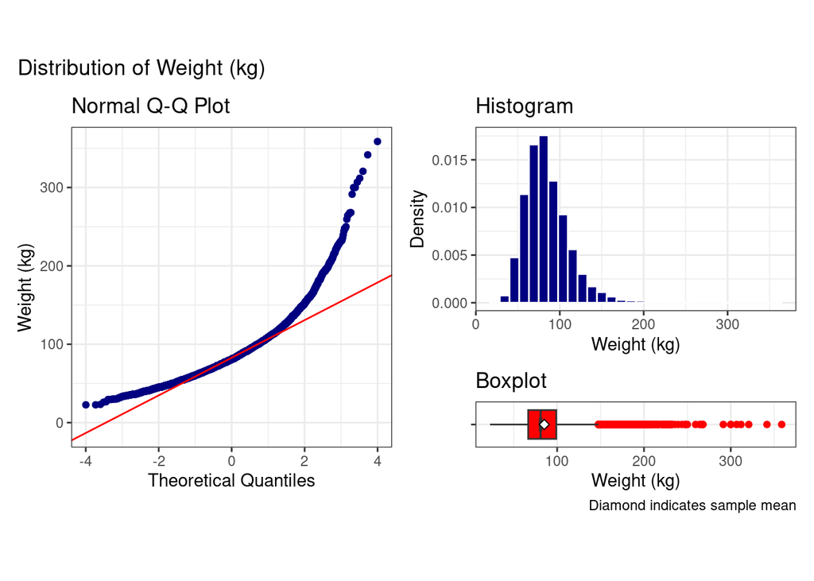

```r
p1 <- ggplot(incl, aes(sample = wt_kg)) +
  geom_qq(col = "navy") + geom_qq_line(col = "red") +
  theme(aspect.ratio = 1) +
  labs(title = "Normal Q-Q Plot",
       y = "Weight (kg)",
       x = "Theoretical Quantiles")

p2 <- ggplot(incl, aes(x = wt_kg)) +
  geom_histogram(aes(y = after_stat(density)),
                 bins = 30, fill = "navy", col = "white") +
  labs(title = "Histogram",
       y = "Density",
       x = "Weight (kg)")

p3 <- ggplot(incl, aes(x = wt_kg, y = "")) +
  geom_boxplot(notch = TRUE, fill = "red", outlier.color = "red") +
  stat_summary(fun = "mean", geom = "point", shape = 23,
               size = 2, fill = "white") +
  labs(title = "Boxplot",
       y = "",
       x = "Weight (kg)",
       caption = "Diamond indicates sample mean")

p1 + (p2 / p3 + plot_layout(heights = c(4,1))) +
  plot_annotation(title = "Distribution of Weight (kg)")
```

```r
pressors_doses |>
  filter(encounter_id %in% incl$encounter_id) |>
  group_by(encounter_id) |>
  mutate(any_nee_0.5 = if_else(any(running_nee_kotani >0.5), "Yes", "No")) |>
  ungroup() |>
  select(encounter_id, any_nee_0.5, pt_rss) |>
  distinct() |>
  tabyl(any_nee_0.5, pt_rss) |>
  rename("Any NEE >0.5" = any_nee_0.5) |>
  adorn_totals() |>
  kable(align = c('ccc'),
        caption = "Patients With Any Occurrence of NEE >0.5 mcg/kg/min by RSS Presence"
        ) |>
  kable_paper(full_width = FALSE)
```

Patients With Any Occurrence of NEE >0.5 mcg/kg/min by RSS Presence

| Any NEE >0.5 | No RSS | RSS Present |
| --- | --- | --- |
| No | 11868 | 0 |
| Yes | 454 | 3410 |
| Total | 12322 | 3410 |

## 12.1 Outcomes Over Time

Calculate and plot refractory septic shock incidence by year.

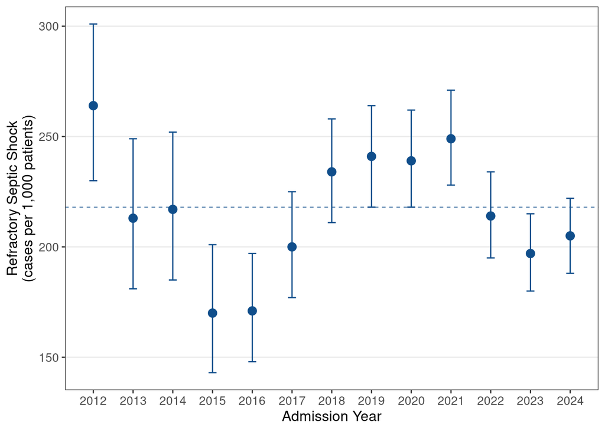

```r
yearly_out <- incl |>
  mutate(admit_year = factor(admit_year)) |>
  select(encounter_id, admit_year, pt_rss, mort_hosp) |>
  group_by(admit_year) |>
  summarise(total_cases = n(),
            rss_cases = sum(pt_rss == "RSS Present"),
            no_rss_cases = sum(pt_rss == "No RSS"),
            rss_mort = sum(pt_rss == "RSS Present" & mort_hosp == "Died"),
            no_rss_mort = sum(pt_rss == "No RSS" & mort_hosp == "Died")) |>
  ungroup() |>
  rowwise() |>
  mutate(
    rss_ci = list(prop.test(rss_cases, total_cases, correct = FALSE)),
    mort_rss_ci = list(prop.test(rss_mort, rss_cases, correct = FALSE)),
    mort_no_rss_ci = list(prop.test(no_rss_mort, no_rss_cases, correct = FALSE))
  ) |>
  ungroup() |>
  mutate(
    rss_est = round_half_up(map_dbl(rss_ci, ~ as.numeric(.x$estimate)),3)*1000,
    rss_lwr = round_half_up(map_dbl(rss_ci, ~ .x$conf.int[1]),3)*1000,
    rss_upr = round_half_up(map_dbl(rss_ci, ~ .x$conf.int[2]),3)*1000,
    mort_rss_est = map_dbl(mort_rss_ci, ~ as.numeric(.x$estimate)),
    mort_rss_lwr = map_dbl(mort_rss_ci, ~ .x$conf.int[1]),
    mort_rss_upr = map_dbl(mort_rss_ci, ~ .x$conf.int[2]),
    mort_no_rss_est = map_dbl(mort_no_rss_ci, ~ as.numeric(.x$estimate)),
    mort_no_rss_lwr = map_dbl(mort_no_rss_ci, ~ .x$conf.int[1]),
    mort_no_rss_upr = map_dbl(mort_no_rss_ci, ~ .x$conf.int[2])
  ) |>
  select(-rss_ci, -mort_rss_ci, -mort_no_rss_ci)

yearly_incidence <- yearly_out |>
  transmute(
    admit_year = as.integer(as.character(admit_year)),
    est = rss_est, lwr = rss_lwr, upr = rss_upr
    )

ggplot(yearly_incidence, aes(x = admit_year, y = est)) +
  scale_y_continuous() +
  scale_x_continuous(breaks = seq(2012, 2024, 1)) +
  #Horizontal dashed line at the overall (total) estimate
  geom_hline(yintercept = 218, color = "dodgerblue4", linewidth = 0.3,
             linetype = "dashed") +
  geom_errorbar(aes(ymin = lwr, ymax = upr), width = 0.2, color = "dodgerblue4") +
  geom_point(size = 3, color = "dodgerblue4") +
  labs(x = "Admission Year",
       y = "Refractory Septic Shock\n(cases per 1,000 patients)") +
  theme(axis.title.x = element_text(size = 12),
        axis.title.y = element_text(size = 12),
        axis.text.x = element_text(size = 10),
        axis.text.y = element_text(size = 10),
        panel.grid.major.x = element_blank(),
        panel.grid.minor.x = element_blank(),
        panel.grid.minor.y = element_blank()
        )
```

```r
ggsave("incidence_trend.tiff", device = "tiff", width=9, height=4,
       units = "in", dpi=300)
```

Calculate refractory septic shock mortality by year and absolute risk difference estimate (and 95% CI) by year.

```r
yearly_mort <- yearly_out |>
  transmute(
    admit_year = as.integer(as.character(admit_year)),
    mort_rss_est, mort_rss_lwr, mort_rss_upr,
    mort_no_rss_est, mort_no_rss_lwr, mort_no_rss_upr
  ) |>
  pivot_longer(
    -admit_year,
    names_to = c("group", "stat"),
    names_pattern = "mort_(rss|no_rss)_(est|lwr|upr)",
    values_to = "value"
  ) |>
  pivot_wider(
    names_from = stat,
    values_from = value
  ) |>
  mutate(group = recode(group, rss = "RSS", no_rss = "No RSS"))

format_ci_str <- function(est, lwr, upr, digits = 1) {
  sprintf(
    paste0("%.", digits, "f (%.", digits, "f, %.", digits, "f)"),
    est, lwr, upr
  )
}

yearly_mort_diff <- yearly_out |>
  transmute(
    admit_year,
    rss_mort, rss_cases, no_rss_mort, no_rss_cases
  ) |>
  rowwise() |>
  mutate(
    tst  = list(prop.test(
      x = c(rss_mort,     no_rss_mort),
      n = c(rss_cases,    no_rss_cases),
      conf.level = 0.95,
      correct = FALSE
    )),
    p1   = unname(tst$estimate[1]),
    p2   = unname(tst$estimate[2]),
    diff_est = p1 - p2,
    diff_lwr = tst$conf.int[1],
    diff_upr = tst$conf.int[2]
  ) |>
  ungroup() |>
  select(admit_year, p1, p2, diff_est, diff_lwr, diff_upr) |>
  mutate(across(starts_with("diff_"), ~ .x * 100)) |>
  mutate(diff_str = format_ci_str(diff_est, diff_lwr, diff_upr, digits = 1)) |>
  mutate(across(c(p1, p2), ~ round_half_up(.x * 100, 1))) |>
  select("Admit Year" = admit_year,
         "RSS Mortality (%)" = p1,
         "Without RSS Mortality (%)" = p2,
         "Absolute Risk Difference (95% CI)" = diff_str
         )

(yearly_mort_diff <- flextable(yearly_mort_diff) |> autofit())
```

| Admit Year | RSS Mortality (%) | Without RSS Mortality (%) | Absolute Risk Difference (95% CI) |
| --- | --- | --- | --- |
| 2012 | 73.7 | 32.5 | 41.1 (32.8, 49.4) |
| 2013 | 77.6 | 30.5 | 47.1 (38.3, 55.8) |
| 2014 | 74.6 | 32.1 | 42.5 (33.8, 51.2) |
| 2015 | 67.3 | 30.6 | 36.7 (27.1, 46.3) |
| 2016 | 65.1 | 22.1 | 43.0 (34.9, 51.2) |
| 2017 | 65.6 | 22.1 | 43.5 (36.5, 50.5) |
| 2018 | 66.9 | 18.7 | 48.2 (42.2, 54.2) |
| 2019 | 62.2 | 20.0 | 42.2 (36.4, 48.1) |
| 2020 | 59.4 | 21.6 | 37.8 (32.1, 43.6) |
| 2021 | 64.3 | 24.8 | 39.5 (34.1, 44.9) |
| 2022 | 65.7 | 21.6 | 44.1 (38.6, 49.6) |
| 2023 | 62.2 | 20.4 | 41.8 (36.7, 46.9) |
| 2024 | 57.6 | 15.4 | 42.2 (37.4, 47.1) |

Export to Word

```r
yearly_mort_diff |> save_as_docx(path = "yearly_mort_diff.docx")
```

Now plot mortality by year by group.

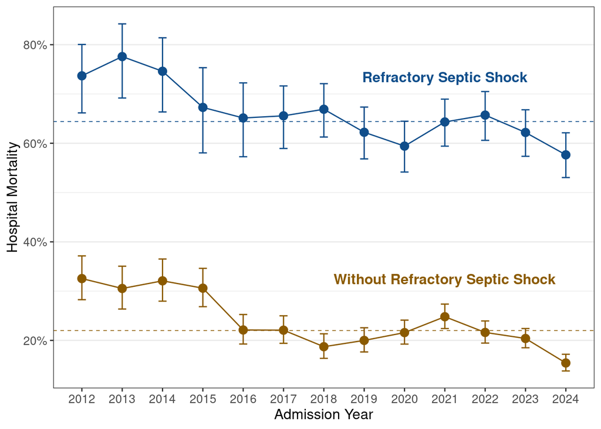

```r
ggplot(yearly_mort, aes(x = admit_year, y = est, color = group)) +
  #Horizontal dashed lines at the estimates by group
  geom_hline(yintercept = 0.644, color = "dodgerblue4", linewidth = 0.3,
             linetype = "dashed") +
  geom_hline(yintercept = 0.22, color = "orange4", linewidth = 0.3,
             linetype = "dashed") +
  geom_errorbar(aes(ymin = lwr, ymax = upr), width = 0.2) +
  geom_point(size = 3) +
  geom_line() +
  scale_y_continuous(labels = percent_format(accuracy = 1)) +
  scale_x_continuous(breaks = seq(2012, 2024, 1)) +
  scale_color_manual(values = c("RSS" = "dodgerblue4", "No RSS" = "orange4"), name = NULL) +
  labs(
    x = "Admission Year",
    y = "Hospital Mortality"
  ) +
  guides(color = "none") +
  annotate("text", x = 2021, y = 0.72, label = "Refractory Septic Shock",
           color = "dodgerblue4", fontface = "bold", size = 4.2, vjust = -0.2) +
  annotate("text", x = 2021, y = 0.31, label = "Without Refractory Septic Shock",
           color = "orange4", fontface = "bold", size = 4.2, vjust = -0.2) +
  theme(axis.title.x = element_text(size = 12),
        axis.title.y = element_text(size = 12),
        axis.text.x = element_text(size = 10),
        axis.text.y = element_text(size = 10),
        panel.grid.major.x = element_blank(),
        panel.grid.minor.x = element_blank()
        )
```

```r
ggsave("mortality_trend.tiff", device = "tiff", width=9, height=4,
       units = "in", dpi=300)
```

## 12.2 Outcomes by Location Size (Bed Count)

```r
beds_out <- incl |>
  mutate(beds =
           fct_relevel(shock_onset_hosp_beds_cat, "<200", "200-499")) |>
  select(encounter_id, beds, pt_rss, mort_hosp) |>
  group_by(beds) |>
  summarise(total_obs = n(),
            rss_cases = sum(pt_rss == "RSS Present"),
            rss_mort = sum(pt_rss == "RSS Present" & mort_hosp == "Died")
            ) |>
  ungroup() |>
  rowwise() |>
  mutate(
    rss_ci = list(prop.test(rss_cases, total_obs, correct = FALSE)),
    mort_rss_ci = list(prop.test(rss_mort, rss_cases, correct = FALSE))
  ) |>
  ungroup() |>
  mutate(
    rss_est = round_half_up(map_dbl(rss_ci, ~ as.numeric(.x$estimate)),3)*1000,
    rss_lwr = round_half_up(map_dbl(rss_ci, ~ .x$conf.int[1]),3)*1000,
    rss_upr = round_half_up(map_dbl(rss_ci, ~ .x$conf.int[2]),3)*1000,
    mort_rss_est = map_dbl(mort_rss_ci, ~ as.numeric(.x$estimate)),
    mort_rss_lwr = map_dbl(mort_rss_ci, ~ .x$conf.int[1]),
    mort_rss_upr = map_dbl(mort_rss_ci, ~ .x$conf.int[2])
  ) |>
  select(-rss_ci, -mort_rss_ci) |>
  mutate(across(starts_with("mort_"), ~ round_half_up(.x * 100, 1)),
         rss_incidence = format_ci_str(rss_est, rss_lwr, rss_upr, digits = 0),
         mort_pct = format_ci_str(mort_rss_est, mort_rss_lwr, mort_rss_upr, digits = 1)
         ) |>
  select(beds, total_obs, rss_incidence, mort_pct) |>
  pivot_longer(
    cols = -beds,
    names_to = "metric",
    values_to = "value",
    values_transform = list(value = as.character),
    values_ptypes = list(value = character())
  ) |>
  pivot_wider(
    names_from = beds,
    values_from = value
  )

beds_out |>
  kable(align = c('lccc'),
        caption = "Outcomes by Hospital Beds"
        ) |>
  kable_paper(full_width = FALSE)
```

Outcomes by Hospital Beds

| metric | <200 | 200-499 | ≥500 |
| --- | --- | --- | --- |
| total_obs | 1906 | 5753 | 8073 |
| rss_incidence | 197 (180, 216) | 196 (186, 207) | 236 (227, 245) |
| mort_pct | 59.3 (54.3, 64.2) | 62.3 (59.4, 65.1) | 66.5 (64.3, 68.6) |

Show number of hospitals by beds

```r
incl |>
  mutate(beds =
           fct_relevel(shock_onset_hosp_beds_cat, "<200", "200-499")
         ) |>
  summarise(
  n_settings = n_distinct(shock_onset_hospital),
  .by = beds
  ) |>
  kable(align = c('lccc'),
        caption = "Hospital Count by Hospital Beds"
        ) |>
  kable_paper(full_width = FALSE)
```

Hospital Count by Hospital Beds

| beds | n_settings |
| --- | --- |
| 200-499 | 10 |
| ≥500 | 3 |
| <200 | 10 |

## 12.3 Outcomes at Large Academic Center

Show outcomes only at the large academic medical center (“Main Campus”).

```r
incl |>
  filter(shock_onset_hospital == "Main Campus") |>
  select(encounter_id, pt_rss, mort_hosp) |>
  summarise(total_obs = n(),
            rss_cases = sum(pt_rss == "RSS Present"),
            rss_mort = sum(pt_rss == "RSS Present" & mort_hosp == "Died")
            ) |>
  rowwise() |>
  mutate(
    rss_ci = list(prop.test(rss_cases, total_obs, correct = FALSE)),
    mort_rss_ci = list(prop.test(rss_mort, rss_cases, correct = FALSE))
  ) |>
  ungroup() |>
  mutate(
    rss_est = round_half_up(map_dbl(rss_ci, ~ as.numeric(.x$estimate)),3)*1000,
    rss_lwr = round_half_up(map_dbl(rss_ci, ~ .x$conf.int[1]),3)*1000,
    rss_upr = round_half_up(map_dbl(rss_ci, ~ .x$conf.int[2]),3)*1000,
    mort_rss_est = map_dbl(mort_rss_ci, ~ as.numeric(.x$estimate)),
    mort_rss_lwr = map_dbl(mort_rss_ci, ~ .x$conf.int[1]),
    mort_rss_upr = map_dbl(mort_rss_ci, ~ .x$conf.int[2])
  ) |>
  select(-rss_ci, -mort_rss_ci) |>
  mutate(across(starts_with("mort_"), ~ round_half_up(.x * 100, 1)),
         rss_incidence = format_ci_str(rss_est, rss_lwr, rss_upr, digits = 0),
         mort_pct = format_ci_str(mort_rss_est, mort_rss_lwr, mort_rss_upr, digits = 1)
         ) |>
  select(total_obs, rss_incidence, mort_pct) |>
  kable(align = c('lccc'),
        caption = "Outcomes at Large Academic Center"
        ) |>
  kable_paper(full_width = FALSE)
```

Outcomes at Large Academic Center

| total_obs | rss_incidence | mort_pct |
| --- | --- | --- |
| 5174 | 241 (229, 252) | 67.2 (64.6, 69.8) |

# 13 Snapshot and Session Info

Call `snapshot()` to update the lockfile with metadata about the currently-used packages in the project library (commented out for rendering). Then producing a summary report of the session information.

```r
#snapshot()
summary(report(sessionInfo()))
```

```
The analysis was done using the R Statistical language (v4.5.1; R
Core Team, 2025) on Red Hat Enterprise Linux 8.10 (Ootpa), using the
packages lme4 (v1.1.37), Matrix (v1.7.3), broom.mixed (v0.2.9.7), Epi
(v2.61), janitor (v2.2.1), flextable (v0.9.11), lubridate (v1.9.4),
vroom (v1.6.5), ggformula (v1.0.1), MKinfer (v1.3), report (v0.6.3),
tibble (v3.3.1), patchwork (v1.3.2), mosaicData (v0.20.4), lattice
(v0.22.7), gtsummary (v2.2.0), naniar (v1.1.0), renv (v1.1.4), ivs
(v0.2.0), ggplot2 (v4.0.2), conflicted (v1.2.0), forcats (v1.0.0),
stringr (v1.6.0), tidyverse (v2.0.0), dplyr (v1.2.0), purrr (v1.2.0),
readr (v2.1.5), scales (v1.4.0), tidyr (v1.3.2) and kableExtra
(v1.4.0).
```

# 14 Package References

```r
cite_packages()
```

```
  - Bates D, Mächler M, Bolker B, Walker S (2015). "Fitting Linear Mixed-Effects Models Using lme4." _Journal of Statistical Software_, *67*(1), 1-48. doi:10.18637/jss.v067.i01 <https://doi.org/10.18637/jss.v067.i01>.
  - Bates D, Maechler M, Jagan M (2025). _Matrix: Sparse and Dense Matrix Classes and Methods_. doi:10.32614/CRAN.package.Matrix <https://doi.org/10.32614/CRAN.package.Matrix>, R package version 1.7-3, <https://CRAN.R-project.org/package=Matrix>.
  - Bolker B, Robinson D (2026). _broom.mixed: Tidying Methods for Mixed Models_. R package version 0.2.9.7, <https://github.com/bbolker/broom.mixed>.
  - Carstensen B, Plummer M, Laara E, Hills M (2025). _Epi: A Package for Statistical Analysis in Epidemiology_. R package version 2.61, <https://CRAN.R-project.org/package=Epi>. Plummer M, Carstensen B (2011). "Lexis: An R Class for Epidemiological Studies with Long-Term Follow-Up." _Journal of Sta…
  - Firke S (2024). _janitor: Simple Tools for Examining and Cleaning Dirty Data_. R package version 2.2.1, <https://github.com/sfirke/janitor>.
  - Gohel D, Skintzos P (2026). _flextable: Functions for Tabular Reporting_. R package version 0.9.11, <https://ardata-fr.github.io/flextable-book/>.
  - Grolemund G, Wickham H (2011). "Dates and Times Made Easy with lubridate." _Journal of Statistical Software_, *40*(3), 1-25. <https://www.jstatsoft.org/v40/i03/>.
  - Hester J, Wickham H, Bryan J (2023). _vroom: Read and Write Rectangular Text Data Quickly_. R package version 1.6.5, <https://vroom.r-lib.org>.
  - Kaplan D, Pruim R (2026). _ggformula: Formula Interface to the Grammar of Graphics_. R package version 1.0.1, <https://github.com/ProjectMOSAIC/ggformula>.
  - Kohl M (2025). _MKinfer: Inferential Statistics_. R package version 1.3, <https://github.com/stamats/MKinfer>.
  - Makowski D, Lüdecke D, Patil I, Thériault R, Ben-Shachar M, Wiernik B (2023). "Automated Results Reporting as a Practical Tool to Improve Reproducibility and Methodological Best Practices Adoption." _CRAN_. doi:10.32614/CRAN.package.report <https://doi.org/10.32614/CRAN.package.report>, <https:/…
  - Müller K, Wickham H (2026). _tibble: Simple Data Frames_. R package version 3.3.1, <https://tibble.tidyverse.org/>.
  - Pedersen T (2025). _patchwork: The Composer of Plots_. R package version 1.3.2, <https://patchwork.data-imaginist.com>.
  - Pruim R, Kaplan D, Horton N (2023). _mosaicData: Project MOSAIC Data Sets_. R package version 0.20.4, <https://github.com/ProjectMOSAIC/mosaicData>.
  - R Core Team (2025). _R: A Language and Environment for Statistical Computing_. R Foundation for Statistical Computing, Vienna, Austria. <https://www.R-project.org/>.
  - Sarkar D (2008). _Lattice: Multivariate Data Visualization with R_. Springer, New York. ISBN 978-0-387-75968-5, <http://lmdvr.r-forge.r-project.org>.
  - Sjoberg D, Whiting K, Curry M, Lavery J, Larmarange J (2021). "Reproducible Summary Tables with the gtsummary Package." _The R Journal_, *13*, 570-580. doi:10.32614/RJ-2021-053 <https://doi.org/10.32614/RJ-2021-053>, <https://doi.org/10.32614/RJ-2021-053>.
  - Tierney N, Cook D (2023). "Expanding Tidy Data Principles to Facilitate Missing Data Exploration, Visualization and Assessment of Imputations." _Journal of Statistical Software_, *105*(7), 1-31. doi:10.18637/jss.v105.i07 <https://doi.org/10.18637/jss.v105.i07>.
  - Ushey K, Wickham H (2025). _renv: Project Environments_. R package version 1.1.4, <https://rstudio.github.io/renv/>.
  - Vaughan D (2023). _ivs: Interval Vectors_. R package version 0.2.0, <https://github.com/DavisVaughan/ivs>.
  - Wickham H (2016). _ggplot2: Elegant Graphics for Data Analysis_. Springer-Verlag New York. ISBN 978-3-319-24277-4, <https://ggplot2.tidyverse.org>.
  - Wickham H (2023). _conflicted: An Alternative Conflict Resolution Strategy_. R package version 1.2.0, <https://conflicted.r-lib.org/>.
  - Wickham H (2023). _forcats: Tools for Working with Categorical Variables (Factors)_. R package version 1.0.0, <https://forcats.tidyverse.org/>.
  - Wickham H (2025). _stringr: Simple, Consistent Wrappers for Common String Operations_. R package version 1.6.0, <https://stringr.tidyverse.org>.
  - Wickham H, Averick M, Bryan J, Chang W, McGowan LD, François R, Grolemund G, Hayes A, Henry L, Hester J, Kuhn M, Pedersen TL, Miller E, Bache SM, Müller K, Ooms J, Robinson D, Seidel DP, Spinu V, Takahashi K, Vaughan D, Wilke C, Woo K, Yutani H (2019). "Welcome to the tidyverse." _Journal of Ope…
  - Wickham H, François R, Henry L, Müller K, Vaughan D (2026). _dplyr: A Grammar of Data Manipulation_. R package version 1.2.0, <https://dplyr.tidyverse.org>.
  - Wickham H, Henry L (2025). _purrr: Functional Programming Tools_. R package version 1.2.0, <https://purrr.tidyverse.org/>.
  - Wickham H, Hester J, Bryan J (2024). _readr: Read Rectangular Text Data_. R package version 2.1.5, <https://readr.tidyverse.org>.
  - Wickham H, Pedersen T, Seidel D (2025). _scales: Scale Functions for Visualization_. R package version 1.4.0, <https://scales.r-lib.org>.
  - Wickham H, Vaughan D, Girlich M (2025). _tidyr: Tidy Messy Data_. R package version 1.3.2, <https://tidyr.tidyverse.org>.
  - Zhu H (2024). _kableExtra: Construct Complex Table with 'kable' and Pipe Syntax_. R package version 1.4.0, <http://haozhu233.github.io/kableExtra/>.
```